# Analysing Sentences Backbone Communities

| Title | Year | Journal | Authors | Number sentences | Words Similarity |
| --- | --- | --- | --- | --- | --- |
| Tax-transfer policies and the voluntary provision of public goods | 1989 | Journal of Public Economics | Boadway R. | 4 | 0.539 |
| [Plausibility in economics](https://doi.org/10.1017/S1478061500002632) | 1986 | Economics and Philosophy | Nooteboom B. | 4 | 0.522 |
| [A Rehabilitation of the Principle of Insufficient Reason](https://http://www.jstor.org/stable/1884581) | 1980 | The Quarterly Journal of Economics | Hans-Werner Sinn | 3 | 0.612 |
| [The “Assumptions” Controversy in Historical Perspective](https://http://www.jstor.org/stable/4224899) | 1980 | Journal of Economic Issues | Abraham Hirsch | 3 | 0.536 |
| The permanent income hypothesis and the real interest rate | 1981 | Economics Letters | Mankiw N. | 2 | 0.511 |
| Further thoughts on testing for causality with econometric models | 1988 | Journal of Econometrics | Swamy P. | 2 | 0.514 |
| [Rank-dependent, subjective expected-utility representations](https://doi.org/10.1007/BF00056140) | 1988 | Journal of Risk and Uncertainty | Luce R. | 2 | 0.539 |
| The economic effects of social security. Toward a reconciliation of theory and measurement | 1987 | Journal of Public Economics | Bernheim B.D. | 2 | 0.557 |
| CBD hypothesis and economies of agglomeration | 1982 | Journal of Economic Theory | Imai H. | 2 | 0.543 |
| Graciela Chichilnisky’s model of North-South trade | 1985 | Journal of Development Economics | Lysy F. | 2 | 0.520 |

| Title | Year | Journal | Authors | Number sentences | Words Similarity |
| --- | --- | --- | --- | --- | --- |
| [The failure of expected-utility theory as a theory of reason](https://doi.org/10.1017/S0266267100004739) | 1994 | Economics and Philosophy | Hampton J. | 11 | 0.539 |
| Lending relationships in Germany - Empirical evidence from survey data | 1998 | Journal of Banking and Finance | Harhoff D. | 5 | 0.529 |
| The parameters of a multiple criteria model of actuarial assumptions for pension plan valuations | 1990 | Insurance Mathematics and Economics | Shapiro A. | 5 | 0.530 |
| [On Justifying Subsidies to the Performing Arts](https://http://www.jstor.org/stable/41804891) | 1994 | Journal of Cultural Economics | DAVID AUSTEN-SMITH | 5 | 0.538 |
| Maximum score estimation of disequilibrium models and the role of anticipatory price-setting | 1998 | Journal of Econometrics | Mayer W. | 4 | 0.533 |
| [Metaconfirmation](https://doi.org/10.1007/BF00136126) | 1996 | Theory and Decision | Zwirn D. | 4 | 0.517 |
| [On the possibility of rational dilemmas: An Axiomatic Approach](https://doi.org/10.1017/S0266267100005095) | 1993 | Economics and Philosophy | Cubitt R. | 4 | 0.526 |
| Comparison-concave utility and following behaviour in social and economic settings | 1998 | Journal of Public Economics | Clark A.E. | 3 | 0.554 |
| Open-end mutual funds and capital-gains taxes | 1998 | Journal of Financial Economics | Barclay M.J. | 3 | 0.566 |
| Board effectiveness and board dissent: A model of the board’s relationship to management and shareholders | 1998 | Journal of Corporate Finance | Warther V. | 3 | 0.531 |

| Title | Year | Journal | Authors | Number sentences | Words Similarity |
| --- | --- | --- | --- | --- | --- |
| [Rational Choice: A Survey of Contributions from Economics and Philosophy](https://http://www.jstor.org/stable/2233854) | 1991 | The Economic Journal | Robert Sugden | 71 | 0.619 |
| [Reason In Economics Versus Ethics](https://doi.org/10.1108/03068299510764235) | 1995 | International Journal of Social Economics | Machan T.R. | 53 | 0.625 |
| [The source of optimality in action](https://http://www.jstor.org/stable/23599909) | 1997 | Cambridge Journal of Economics | J. W. Fedderke | 51 | 0.662 |
| [Information, knowledge vision and theories of the firm](https://doi.org/10.1093/icc/3.3.713) | 1994 | Industrial and Corporate Change | Fransman M. | 44 | 0.649 |
| [Rationality, Bounded or not, and Institutional Analysis](https://http://www.jstor.org/stable/40751359) | 1990 | Journal of Institutional and Theoretical Economics (JITE) / Zeitschrift für die gesamte Staatswissenschaft | Ekkehart Schlicht | 44 | 0.638 |
| [On the possibility of rational dilemmas: An Axiomatic Approach](https://doi.org/10.1017/S0266267100005095) | 1993 | Economics and Philosophy | Cubitt R. | 41 | 0.612 |
| [Why Bounded Rationality?](https://http://www.jstor.org/stable/2729218) | 1996 | Journal of Economic Literature | John Conlisk | 40 | 0.640 |
| [It’s Only Rational: An Essay on the Logic of Social Rationalization](https://http://www.jstor.org/stable/40428297) | 1994 | International Journal of Political Economy | Tilla Siegel, Nicholas Levis | 39 | 0.558 |
| Learning rules of thumb or learning more rational rules | 1999 | Journal of Economic Behavior and Organization | Slonim R.L. | 37 | 0.601 |
| [Is There a Place for the Rational Actor? A Geographical Critique of the Rational Choice Paradigm](https://http://www.jstor.org/stable/144038) | 1992 | Economic Geography | Trevor J. Barnes, Eric Sheppard | 35 | 0.619 |

| Title | Year | Journal | Authors | Number sentences | Words Similarity |
| --- | --- | --- | --- | --- | --- |
| [Collective, universal, and joint rationality](https://www.jstor.org/stable/10.2307/41107861) | 2007 | Social Choice and Welfare | Paul Weirich | 186 | 0.635 |
| [Symposium on explanations and social ontology 1: Rational choice theory and social explanation](https://doi.org/10.1017/S026626710200202X) | 2002 | Economics and Philosophy | Ferejohn J. | 68 | 0.613 |
| [Irrationality and the Criminal Sanction](https://www.jstor.org/stable/10.2307/3655320) | 2004 | Supreme Court Economic Review | Michael Edmund O’Neill | 67 | 0.624 |
| [On Institutional Rationality](https://http://www.jstor.org/stable/4227993) | 2004 | Journal of Economic Issues | William H. Redmond | 57 | 0.619 |
| The self as a problem: The intra-personal coordination of conflicting desires | 2001 | Journal of Socio Economics | Moldoveanu M. | 55 | 0.601 |
| [Beyond the rationality of economic man, toward the true rationality of human man](https://doi.org/10.1016/j.socec.2008.05.001) | 2008 | Journal of Socio Economics | Tomer J. | 52 | 0.639 |
| Sublime Simon: The consistent vision of economic psychology’s Nobel laureate | 2001 | Journal of Economic Psychology | Augier M. | 47 | 0.621 |
| [Natural selection and rational decision: Two concepts of optimization](https://doi.org/10.1007/s00191-008-0120-x) | 2009 | Journal of Evolutionary Economics | Khalil E. | 46 | 0.602 |
| [Rationality, Imagination and Intelligence: Some Boundaries in Human Decision-making](https://doi.org/10.1093/icc/9.4.659) | 2000 | Industrial and Corporate Change | Augier M. | 45 | 0.631 |
| [Rational Irrationality: A Framework for the Neoclassical-Behavioral Debate](https://http://www.jstor.org/stable/40325987) | 2000 | Eastern Economic Journal | Bryan Caplan | 44 | 0.615 |

| Title | Year | Journal | Authors | Number sentences | Words Similarity |
| --- | --- | --- | --- | --- | --- |
| [How the left prospers from prosperity](https://doi.org/10.1016/j.ejpoleco.2007.07.003) | 2008 | European Journal of Political Economy | Markussen S. | 6 | 0.568 |
| [Bounded rationality, cognitive maps, and trial and error learning](https://doi.org/10.1016/j.jebo.2007.06.002) | 2008 | Journal of Economic Behavior and Organization | Nelson R. | 6 | 0.547 |
| Essays on disclosure | 2001 | Journal of Accounting and Economics | Verrecchia R.E. | 5 | 0.542 |
| Growth, environment, and culture - Encompassing competing ideologies in one ‘new growth’ model | 2002 | Ecological Economics | Hart R. | 5 | 0.555 |
| Endogenous markups and the effects of income taxation: Theory and evidence from OECD countries | 2000 | Journal of Public Economics | Wu Y. | 4 | 0.561 |
| How many franchises in a market? | 2001 | International Journal of Industrial Organization | Rysman M. | 4 | 0.535 |
| Speculation and the decision to abandon a fixed exchange rate regime | 2002 | Journal of International Economics | Pastine I. | 4 | 0.544 |
| Market access, economic geography and comparative advantage: An empirical test | 2003 | Journal of International Economics | Davis D. | 4 | 0.551 |
| On the theory of reference-dependent preferences | 2003 | Journal of Economic Behavior and Organization | Munro A. | 4 | 0.529 |
| The idea trap: The political economy of growth divergence | 2003 | European Journal of Political Economy | Caplan B. | 4 | 0.548 |

### Most cited references in the backbone community

| First Author | Year | Journal | Citation by article | Citation by sentence |
| --- | --- | --- | --- | --- |
| STIGLER-G | 1961 | J POLITICAL EC | 13 | 1131 |
| KREPS-D | 1982 | J EC THEORY | 10 | 720 |
| BERNHEIM-B | 1984 | ECONOMETRICA | 2 | 514 |
| PEARCE-D | 1984 | ECONOMETRICA | 2 | 514 |
| AUMANN-R | 1987 | ECONOMETRICA | 2 | 514 |
| WHITE-H | 1980 | ECONOMETRICA | 60 | 180 |
| BECKER-G | 1965 | EC J | 2 | 172 |
| TVERSKY-A | 1974 | SCIENCE | 2 | 172 |
| JENSEN-M | 1976 | J FINANCIAL EC | 56 | 168 |
| MUTH-J | 1961 | ECONOMETRICA | 40 | 120 |
| HANSEN-L | 1982 | ECONOMETRICA | 58 | 116 |
| LUCAS-R | 1988 | J MONETARY ECON | 53 | 106 |
| ROMER-P | 1986 | J POLIT ECON | 51 | 102 |
| DIXIT-A | 1977 | AM EC REV | 46 | 92 |
| ENGLE-R | 1982 | ECONOMETRICA | 41 | 82 |

| First Author | Year | Journal | Citation by article | Citation by sentence |
| --- | --- | --- | --- | --- |
| WILLIAMSON-O | 1985 | EC I CAPITALISM FIRM | 202 | 29290 |
| NELSON-R | 1982 | EVOLUTIONARY THEORY | 170 | 17000 |
| WILLIAMSON-O | 1975 | MARKETS HIERARCHIES | 149 | 16390 |
| SIMON-H | 1957 | MODELS MAN SOCIAL RA | 77 | 10241 |
| KEYNES-J | 1936 | GENERAL THEORY EMPLO | 106 | 8162 |
| FRIEDMAN-M | 1953 | ESSAYS POSITIVE EC | 94 | 6768 |
| ARROW-K | 1951 | SOCIAL CHOICE INDIVI | 33 | 6402 |
| SAVAGE-L | 1954 | FDN STAT | 53 | 5830 |
| RAWLS-J | 1971 | THEORY JUSTICE | 63 | 5292 |
| VONNEUMANN-J | 1944 | THEORY GAMES EC BEHA | 25 | 4650 |
| BECKER-G | 1976 | EC APPROACH HUMAN BE | 43 | 3870 |
| KREPS-D | 1990 | COURSE MICROECONOMIC | 54 | 2916 |
| FRANK-R | 1988 | PASSIONS REASON | 34 | 2414 |
| SCHELLING-T | 1960 | STRATEGY CONFLICT | 33 | 2343 |
| NORTH-D | 1990 | I I CHANGE EC PERFOR | 71 | 1917 |

### Most cited references per kmean clusters

| First Author | Year | Journal | Citation by article | Citation by sentence |
| --- | --- | --- | --- | --- |
| BOULDING-K | 1941 | EC ANAL | 1 | 8 |
| DEWEY-J | 1929 | EXPERIENCE NATURE | 1 | 8 |
| FRAZER-L | 1937 | EC THOUGHT LANGUAGE | 1 | 8 |
| JOHNSON-G | 1944 | J FARM ECON | 1 | 8 |
| KNIGHT | 1940 | J POLITICAL EC | 1 | 8 |
| KNIGHT | 1941 | J POLITICAL EC | 1 | 8 |
| SHEPHERD-G | 1941 | AGR PRICE ANAL | 1 | 8 |
| FRANKELO | 1941 | NATURE | 1 | 4 |
| HUXLEYJ | 1942 | EVOLUTION | 1 | 4 |
| HUXLEYTH | 1880 | LAY SERMONS | 1 | 4 |

| First Author | Year | Journal | Citation by article | Citation by sentence |
| --- | --- | --- | --- | --- |
| HICKSJR | 1939 | VALUE CAPITAL 3 | 6 | 18 |
| HUTCHISON-T | 1938 | SIGNIFICANCE BASIC P | 2 | 16 |
| PARSONS | 1945 | WIS EXP STA RES B | 2 | 16 |
| HAYEKFA | 1941 | ECONOMICA MAY | 3 | 9 |
| KEYNESJM | 1936 | GEN THEORY EMPLOYMEN | 3 | 9 |
| LERNERAP | 1944 | EC CONTROL | 3 | 9 |
| BOWLEY-A | 1937 | ELEMENTS STAT | 1 | 8 |
| CHADDOCK-R | 1925 | PRINCIPLES METHODS S | 1 | 8 |
| DEWEY-J | 1938 | LOGIC THEORY INQUIRY | 1 | 8 |
| SALTER-L | 1948 | THESIS | 1 | 8 |

| First Author | Year | Journal | Citation by article | Citation by sentence |
| --- | --- | --- | --- | --- |
| CROCEB | 1913 | PHILOS PRACTICAL EC | 1 | 8 |
| HARROD | 1946 | EC J MAR | 1 | 8 |
| KALECKI | 1945 | EC FULL EMPLOYMENT | 1 | 8 |
| VONNEUMANNJ | 1944 | THEORY GAMES EC BEHA | 1 | 8 |
| MERTON-R | 1938 | AM SOCIOL REV | 1 | 4 |
| MERTONRK | 1936 | AM SOCIOL REV | 1 | 4 |
| HARRISAL | 1932 | J POLIT ECON | 1 | 4 |
| HARRISAL | 1934 | J POLIT ECON | 1 | 4 |
| PARSONST | 1928 | J POLIT ECON | 1 | 4 |
| DAVISAK | 1944 | AM SOCIOL REV | 1 | 4 |

| First Author | Year | Journal | Citation by article | Citation by sentence |
| --- | --- | --- | --- | --- |
| SMITHA | 1812 | THEORY MORAL SENTI 6 | 3 | 12 |
| DANNAFC | 1946 | PREVIDENZA SOCIALE | 1 | 8 |
| DINARDIG | 1941 | GIORNALE EC NOV | 1 | 8 |
| DINARDIG | 1942 | GIORNALE EC JAN | 1 | 8 |
| FRIEDMAN | 1946 | AM EC REV SEP | 1 | 8 |
| SAMUELSONP | 1941 | ECONOMETRICA APR | 1 | 8 |
| MORGENTHAU-H | 1946 | SCI MAN VERSUS POWER | 2 | 4 |
| CARVERTN | 1928 | PRESENT EC REVOLUTIO | 1 | 4 |
| DAVISAK | 1915 | IMPERIAL GERMANY | 1 | 4 |
| DAVISAK | 1917 | NATURE PEACE | 1 | 4 |

| First Author | Year | Journal | Citation by article | Citation by sentence |
| --- | --- | --- | --- | --- |
| LUNDBERGGA | 1947 | CAN SCI SAVE US | 1 | 13 |
| FRANKELO | 1941 | NATURE | 1 | 7 |
| HUXLEYJ | 1942 | EVOLUTION | 1 | 7 |
| HUXLEYTH | 1880 | LAY SERMONS | 1 | 7 |
| MENGER | 1933 | COLLECT WORKS | 1 | 7 |
| WADDINGTON | 1941 | SCI ATTITUDE | 1 | 7 |
| WADDINGTON | 1942 | SCI ETHICS | 1 | 7 |
| HALEVYE | 1928 | GROWTH PHILOSOPHIC R | 1 | 5 |
| GREGORYTE | 1921 | ECONOMICA | 1 | 5 |
| OLEARYJJ | 1942 | J POLITICAL EC | 1 | 5 |

| First Author | Year | Journal | Citation by article | Citation by sentence |
| --- | --- | --- | --- | --- |
| HAYEKFA | 1941 | ECONOMICA MAY | 3 | 39 |
| HAYEKFA | 1942 | ECONOMICA AUG | 1 | 13 |
| COLLINGWOODRG | 1925 | INT J ETHICS | 1 | 12 |
| SMITHA | 1812 | THEORY MORAL SENTI 6 | 3 | 9 |
| CARNAP | 1942 | INTRO SEMANTICS | 1 | 7 |
| FLORENCEPS | 1933 | LOGIC IND ORG | 1 | 7 |
| HUXLEYJ | 1942 | EVOLUTION | 1 | 7 |
| KRAFTV | 1925 | GRUNDFORMEN WISSENSC | 1 | 7 |
| RAVEN | 1943 | SCI RELIG FUTURE | 1 | 7 |
| WEBERM | 1922 | GES SCHR WISSENSCHAF | 1 | 7 |

| First Author | Year | Journal | Citation by article | Citation by sentence |
| --- | --- | --- | --- | --- |
| KEYNESJM | 1936 | GENERAL THEORY EMPLO | 1 | 7 |
| JAMESW | 1911 | PRAGMATISME | 1 | 7 |
| VINERJ | 1932 | Z NATIONALOKONOMIE | 1 | 7 |
| *AMECASS | 1948 | AM EC ASS PAP P | 1 | 7 |
| BRIDGMANPW | 1937 | LOGIC MODERN PHYS | 1 | 7 |
| EINSTEIN | 1938 | EVOLUTION PHYS | 1 | 7 |
| JAMESW | 1910 | PRINCIPLES PSYCHOL | 1 | 7 |
| LEWISCI | 1946 | ANAL KNOWLEDGE VALUA | 1 | 7 |
| RICARDOD | 1923 | EC ESSAYS | 1 | 7 |
| RUSSELLB | 1912 | PROBLEMS PHILOS | 1 | 7 |

| First Author | Year | Journal | Citation by article | Citation by sentence |
| --- | --- | --- | --- | --- |
| VONNEUMANN-J | 1947 | THEORY GAMES EC BEHA | 11 | 22 |
| PARSONST | 1937 | STRUCTURE SOCIAL ACT | 3 | 21 |
| GALBRAITH-J | 1952 | AM CAPITALISM | 3 | 15 |
| MACHLUPF | 1946 | MARGINAL ANAL EMPIRI | 2 | 14 |
| POPPERKR | 1944 | ECONOMICA | 2 | 14 |
| POPPER | 1945 | OPEN SOC ITS ENEMIES | 2 | 14 |
| LITTLEIMD | 1950 | CRITIQUE WELFARE EC | 4 | 12 |
| GOODMANL | 1952 | AM J SOCIOLOGY | 2 | 10 |
| HILDRETHC | 1953 | ECONOMETRICA | 2 | 10 |
| LITTLEIMD | 1952 | J POLITICAL EC | 2 | 10 |

| First Author | Year | Journal | Citation by article | Citation by sentence |
| --- | --- | --- | --- | --- |
| VONMISESL | 1949 | HUMAN ACTION TREATIS | 1 | 27 |
| KNIGHTFH | 1951 | AM EC REV MAR | 1 | 27 |
| CUVILLIERA | 1951 | SOCIOLOGIE CONNAISSA | 1 | 27 |
| FISHERAGB | 1945 | EC PROGR SOCIAL SECU | 1 | 27 |
| SAMUELSONP | 1951 | ECONOMICS | 1 | 27 |
| FRIEDMAN-M | 1948 | J POLITICAL ECONOMY | 1 | 13 |
| HICKS-J | 1935 | ECONOMICA | 1 | 13 |
| MARSCHAK-J | 1946 | J POLIT ECON | 1 | 13 |
| MARSCHAK-J | 1949 | AM ECON REV | 1 | 13 |
| MARSCHAK-J | 1938 | ECONOMETRICA | 1 | 13 |

| First Author | Year | Journal | Citation by article | Citation by sentence |
| --- | --- | --- | --- | --- |
| VONNEUMANN-J | 1947 | THEORY GAMES EC BEHA | 7 | 91 |
| KNIGHT-F | 1921 | RISK UNCERTAINTY PRO | 3 | 39 |
| ARROW-K | 1951 | COWLES COMMISSION MO | 3 | 30 |
| ALLAISM | 1952 | INT S CTR NAT RECH S | 1 | 27 |
| ELVINGERF | 1930 | METHODES MODERNES VE | 1 | 27 |
| FRIEDMANM | 1948 | J POLITICAL EC AUG | 1 | 27 |
| GOLDENWEISEREA | 1951 | MONEY TRADE EC GROWT | 1 | 27 |
| MARSCHAKJ | 1950 | ECONOMETRICA APR | 1 | 27 |
| MARSCHAKJ | 1932 | ARCH SOZIALWISSE JUN | 1 | 27 |
| PIAGET | 1939 | J PSYCHOL | 1 | 27 |

| First Author | Year | Journal | Citation by article | Citation by sentence |
| --- | --- | --- | --- | --- |
| ARROW-K | 1961 | REV ECONOMICS STATIS | 2 | 4 |
| OI-W | 1962 | J POLITICAL EC | 4 | 4 |
| SCHULTZ-T | 1961 | AM ECON REV | 4 | 4 |
| *INTMONFUND | 1964 | 1964 ANN REP | 1 | 4 |
| RAPOPORT-A | 1954 | OPERATIONAL PHILOS | 1 | 4 |
| BACK-W | 1960 | J FARM EC DEC | 1 | 4 |
| ARROW-K | 1961 | REV ECONOMICS STATIS | 3 | 3 |
| VONNEUMANN-J | 1945 | REV ECON STUD | 3 | 3 |
| ANDO-A | 1963 | AM EC REV | 3 | 3 |
| SAMUELSON-P | 1954 | REV EC STATISTICS | 1 | 3 |

| First Author | Year | Journal | Citation by article | Citation by sentence |
| --- | --- | --- | --- | --- |
| ARROW-K | 1951 | ACTIVITY ANAL PRODUC | 12 | 48 |
| SAMUELSON-P | 1947 | F EC ANAL | 10 | 40 |
| DENISON-E | 1962 | SOURCES EC GROWTH US | 6 | 24 |
| KOOPMANS-T | 1957 | 3 ESSAYS STATE EC SC | 6 | 24 |
| MEADE-J | 1955 | THEORY INT EC POLICY | 10 | 20 |
| DORFMAN-R | 1958 | LINEAR PROGRAMMING E | 5 | 20 |
| HICKS-J | 1950 | CONTRIBUTION THEORY | 5 | 20 |
| LEIBENSTEIN-H | 1957 | EC BACKWARDNESS EC G | 5 | 20 |
| NELSON-R | 1959 | J BUSINESS | 5 | 20 |
| SAMUELSON-P | 1958 | J POLITICAL EC | 5 | 20 |

| First Author | Year | Journal | Citation by article | Citation by sentence |
| --- | --- | --- | --- | --- |
| MARRIS-R | 1957 | REV ECON STUD | 1 | 12 |
| HOTELLING-H | 1935 | ECONOMETRICA JAN | 1 | 12 |
| SAMUELSON-P | 1947 | F EC ANAL | 1 | 12 |
| NASH-J | 1950 | ECONOMICTRICA | 1 | 11 |
| MAY-K | 1954 | ECONOMETRIC | 1 | 11 |
| TULLOCK-G | 1964 | OXFORD ECONOMIC PAPE | 1 | 11 |
| HARSANYI-J | 1955 | J POLITICAL EC | 1 | 11 |
| ANSCOMBE-F | 1963 | ANN MATH STAT | 1 | 11 |
| NASH-J | 1951 | ANN MATH | 1 | 11 |
| HARSANYI-J | 1953 | J POLITICAL EC | 1 | 11 |

| First Author | Year | Journal | Citation by article | Citation by sentence |
| --- | --- | --- | --- | --- |
| ARROW-K | 1951 | SOCIAL CHOICE INDIVI | 7 | 56 |
| EDWARDS-W | 1954 | PSYCHOL B | 3 | 36 |
| ROTHENBERG-J | 1961 | MEASUREMENT SOCIAL W | 4 | 32 |
| SAVAGE-L | 1954 | FDN STAT | 5 | 25 |
| BLACK-D | 1958 | THEORY COMMITTEES EL | 3 | 24 |
| BUCHANAN-J | 1962 | CALCULUS CONSENT LOG | 3 | 24 |
| MUSGRAVE-R | 1959 | THEORY PUBLIC FINANC | 3 | 24 |
| DOWNS-A | 1957 | ECONOMIC THEORY DEMO | 2 | 16 |
| ARROW-K | 1959 | ALLOCATION EC RESOUR | 3 | 15 |
| POPPER-K | 1959 | LOGIC SCIENTIFIC DIS | 2 | 12 |

| First Author | Year | Journal | Citation by article | Citation by sentence |
| --- | --- | --- | --- | --- |
| BECKER-G | 1965 | EC J | 1 | 34 |
| LINDBLOM-C | 1959 | PUBLIC ADMIN REV | 1 | 34 |
| TVERSKY-A | 1974 | SCIENCE | 1 | 34 |
| SIMON-H | 1955 | QUART J ECONOMICS | 1 | 34 |
| TAYLOR-R | 1975 | DECISION SCI | 1 | 34 |
| SIMON-H | 1973 | ARTIFICIAL INTELLIGE | 1 | 34 |
| SLOVIC-P | 1977 | ANNU REV PSYCHOL | 1 | 34 |
| STIGLER-G | 1977 | AM EC REV | 1 | 34 |
| STIGLER-G | 1961 | J POLITICAL EC | 1 | 34 |
| COHEN-M | 1972 | ADM SCI Q | 1 | 34 |

| First Author | Year | Journal | Citation by article | Citation by sentence |
| --- | --- | --- | --- | --- |
| MARCH-J | 1958 | ORGANIZATIONS | 11 | 374 |
| SEN-A | 1970 | COLLECTIVE CHOICE SO | 21 | 357 |
| CYERT-R | 1963 | BEHAVIORAL THEORY FI | 9 | 306 |
| SIMON-H | 1957 | MODELS MAN SOCIAL RA | 8 | 272 |
| ARROW-K | 1963 | SOCIAL CHOICE INDIVI | 20 | 260 |
| OLSON-M | 1965 | LOGIC COLLECTIVE ACT | 7 | 238 |
| SAVAGE-L | 1954 | FDN STAT | 7 | 238 |
| WILLIAMSON-O | 1975 | MARKETS HIERARCHIES | 7 | 238 |
| FRIEDMAN-M | 1953 | ESSAYS POSITIVE EC | 16 | 176 |
| SPENCE-A | 1974 | MARKET SIGNALLING | 5 | 170 |

| First Author | Year | Journal | Citation by article | Citation by sentence |
| --- | --- | --- | --- | --- |
| STIGLER-G | 1961 | J POLITICAL EC | 11 | 11 |
| MUTH-J | 1961 | ECONOMETRICA | 11 | 11 |
| COASE-R | 1960 | J LAW EC | 10 | 10 |
| SAMUELSON-P | 1954 | REV EC STATISTICS | 10 | 10 |
| BARRO-R | 1971 | AM EC REV | 9 | 9 |
| LANCASTER-K | 1966 | J POLITICAL EC | 8 | 8 |
| FRIEDMAN-M | 1968 | AER | 7 | 7 |
| BAUMOL-W | 1952 | Q J EC | 7 | 7 |
| LEIBENSTEIN-H | 1966 | AM EC REV | 7 | 7 |
| TOBIN-J | 1972 | AM EC REV | 7 | 7 |

| First Author | Year | Journal | Citation by article | Citation by sentence |
| --- | --- | --- | --- | --- |
| SAMUELSON-P | 1947 | FOUNDATIONS ECONOMIC | 19 | 76 |
| HICKS-J | 1956 | REVISION DEMAND THEO | 12 | 48 |
| LEIJONHUFVUD-A | 1968 | KEYNESIAN ECONOMICS | 16 | 48 |
| DEBREU-G | 1959 | THEORY VALUE | 18 | 36 |
| SAMUELSON-P | 1965 | ECONOMETRICA | 9 | 36 |
| KEYNES-J | 1936 | GENERAL THEORY EMPLO | 17 | 34 |
| KUHN-T | 1962 | STRUCTURE SCIENTIFIC | 8 | 32 |
| NAGEL-E | 1961 | STRUCTURE SCIENCE | 8 | 32 |
| FRIEDMAN-M | 1969 | OPTIMUM QUANTITY MON | 16 | 32 |
| THEIL-H | 1971 | AM ECONOMIC REV | 8 | 32 |

| First Author | Year | Journal | Citation by article | Citation by sentence |
| --- | --- | --- | --- | --- |
| BECKER-G | 1965 | EC J | 1 | 52 |
| TVERSKY-A | 1974 | SCIENCE | 1 | 52 |
| ZAJONC-R | 1980 | AM PSYCHOL | 1 | 52 |
| STIGLER-G | 1961 | J POLITICAL EC | 1 | 52 |
| HAUSMAN-J | 1979 | BELL J ECON | 1 | 52 |
| THALER-R | 1981 | ECON LETT | 1 | 52 |
| MARCH-J | 1978 | BELL J EC | 1 | 52 |
| LEWIS-W | 1954 | MANCHESTER SCH EC SO | 1 | 52 |
| CONLISK-J | 1988 | J ECON BEHAV ORGAN | 1 | 52 |
| CONLISK-J | 1980 | J ECON BEHAV ORGAN | 1 | 52 |

| First Author | Year | Journal | Citation by article | Citation by sentence |
| --- | --- | --- | --- | --- |
| SIMON-H | 1957 | MODELS MAN SOCIAL RA | 21 | 1092 |
| DOWNS-A | 1957 | EC THEORY DEMOCRACY | 28 | 1092 |
| WILLIAMSON-O | 1985 | EC I CAPITALISM FIRM | 20 | 1040 |
| BECKER-G | 1976 | EC APPROACH HUMAN BE | 16 | 624 |
| ARROW-K | 1974 | LIMITS ORG | 11 | 572 |
| ELSTER-J | 1979 | ULYSSES AND SIRENS | 11 | 572 |
| CYERT-R | 1963 | BEHAVIORAL THEORY FI | 14 | 532 |
| LUCE-R | 1957 | GAMES DECISIONS | 24 | 456 |
| FRIEDMAN-M | 1953 | ESSAYS POSITIVE EC | 21 | 441 |
| GEORGESCUROEGEN-N | 1971 | ENTROPY LAW EC PROCE | 11 | 418 |

| First Author | Year | Journal | Citation by article | Citation by sentence |
| --- | --- | --- | --- | --- |
| LUCAS-R | 1972 | J EC THEORY | 15 | 15 |
| MUTH-J | 1961 | ECONOMETRICA | 15 | 15 |
| ROSS-S | 1976 | J EC THEORY | 13 | 13 |
| SHARPE-W | 1964 | J FINANCE | 12 | 12 |
| DORNBUSCH-R | 1976 | J POLITICAL EC | 11 | 11 |
| LUCAS-R | 1973 | AER | 11 | 11 |
| BARRO-R | 1974 | J POLITICAL EC | 11 | 11 |
| PELTZMAN-S | 1976 | J LAW EC | 10 | 10 |
| BLACK-F | 1973 | J POLITICAL EC | 10 | 10 |
| LINTNER-J | 1965 | REV EC STATISTICS | 10 | 10 |

| First Author | Year | Journal | Citation by article | Citation by sentence |
| --- | --- | --- | --- | --- |
| KEYNES-J | 1936 | GENERAL THEORY EMPLO | 22 | 44 |
| SAMUELSON-P | 1947 | F EC ANAL | 14 | 42 |
| ARROW-K | 1971 | ESSAYS THEORY RISK B | 16 | 32 |
| DEBREU-G | 1959 | THEORY VALUE | 13 | 26 |
| LUCE-R | 1957 | GAMES DECISIONS INTR | 8 | 24 |
| WILLIAMSON-O | 1975 | MARKETS HIERARCHIES | 12 | 24 |
| FRIEDMAN-M | 1953 | ESSAYS POSITIVE EC | 8 | 24 |
| DOWNS-A | 1957 | EC THEORY DEMOCRACY | 11 | 22 |

| First Author | Year | Journal | Citation by article | Citation by sentence |
| --- | --- | --- | --- | --- |
| ENGLE-R | 1987 | ECONOMETRICA | 23 | 23 |
| HANSEN-L | 1982 | ECONOMETRICA | 21 | 21 |
| WHITE-H | 1980 | ECONOMETRICA | 19 | 19 |
| ROMER-P | 1986 | J POLIT ECON | 19 | 19 |
| JENSEN-M | 1976 | J FINANCIAL EC | 17 | 17 |
| NELSON-C | 1982 | J MONETARY EC | 16 | 16 |
| LUCAS-R | 1988 | J MONETARY ECON | 14 | 14 |
| MUTH-J | 1961 | ECONOMETRICA | 14 | 14 |
| ENGLE-R | 1982 | ECONOMETRICA | 13 | 13 |
| MYERS-S | 1984 | J FINANCIAL EC | 13 | 13 |

| First Author | Year | Journal | Citation by article | Citation by sentence |
| --- | --- | --- | --- | --- |
| AMEMIYA-T | 1985 | ADV ECONOMETRICS | 13 | 52 |
| MADDALA-G | 1983 | LTD DEPENDENT QUALIT | 12 | 48 |
| WILLIAMSON-O | 1985 | EC I CAPITALISM FIRM | 23 | 46 |
| KEYNES-J | 1936 | GENERAL THEORY EMPLO | 23 | 46 |
| TIROLE-J | 1988 | THEORY IND ORG | 23 | 46 |
| NELSON-R | 1982 | EVOLUTIONARY THEORY | 20 | 40 |
| FRANK-R | 1985 | CHOOSING RIGHT POND | 13 | 39 |
| BLANCHARD-O | 1989 | LECT MACROECONOMICS | 18 | 36 |
| RAWLS-J | 1971 | THEORY JUSTICE | 17 | 34 |
| WILLIAMSON-O | 1975 | MARKETS HIERARCHIES | 11 | 33 |

| First Author | Year | Journal | Citation by article | Citation by sentence |
| --- | --- | --- | --- | --- |
| MACHINA-M | 1989 | J ECON LIT | 1 | 71 |
| TVERSKY-A | 1986 | J BUS | 1 | 71 |
| BELL-D | 1982 | OPERATIONS RES | 1 | 71 |
| KREPS-D | 1982 | ECONOMETRICA | 1 | 71 |
| SELTEN-R | 1978 | THEORY DECISION | 1 | 71 |
| HARSANYI-J | 1973 | INT J GAME THEORY | 1 | 71 |
| SMITH-M | 1987 | MIND | 1 | 71 |
| BERNHEIM-B | 1984 | ECONOMETRICA | 1 | 71 |
| PEARCE-D | 1984 | ECONOMETRICA | 1 | 71 |
| CRAWFORD-V | 1990 | ECONOMETRICA | 1 | 71 |

| First Author | Year | Journal | Citation by article | Citation by sentence |
| --- | --- | --- | --- | --- |
| WILLIAMSON-O | 1985 | EC I CAPITALISM FIRM | 90 | 3960 |
| KEYNES-J | 1936 | GENERAL THEORY EMPLO | 44 | 3124 |
| NELSON-R | 1982 | EVOLUTIONARY THEORY | 61 | 3111 |
| SAVAGE-L | 1954 | FDN STAT | 41 | 2911 |
| WILLIAMSON-O | 1975 | MARKETS HIERARCHIES | 60 | 2640 |
| FRANK-R | 1988 | PASSIONS REASON | 34 | 2414 |
| RAWLS-J | 1971 | THEORY JUSTICE | 34 | 2414 |
| SCHELLING-T | 1960 | STRATEGY CONFLICT | 33 | 2343 |
| KREPS-D | 1990 | COURSE MICROECONOMIC | 43 | 2193 |
| FRIEDMAN-M | 1953 | ESSAYS POSITIVE EC | 49 | 1813 |

| First Author | Year | Journal | Citation by article | Citation by sentence |
| --- | --- | --- | --- | --- |
| SEN-A | 1977 | PHILOS PUBLIC AFFAIR | 1 | 186 |
| NASH-J | 1950 | P NATIONAL ACADEMY S | 1 | 186 |
| BERNHEIM-B | 1984 | ECONOMETRICA | 1 | 186 |
| PEARCE-D | 1984 | ECONOMETRICA | 1 | 186 |
| AUMANN-R | 1987 | ECONOMETRICA | 1 | 186 |
| KADANE-J | 1982 | MANAGE SCI | 1 | 186 |
| BROOME-J | 1987 | J PHILOS | 1 | 186 |
| COSMIDES-L | 1989 | COGNITION | 1 | 57 |
| TVERSKY-A | 1981 | SCIENCE | 1 | 57 |
| KALBERG-S | 1980 | AM J SOCIOL | 1 | 57 |

| First Author | Year | Journal | Citation by article | Citation by sentence |
| --- | --- | --- | --- | --- |
| ARROW-K | 1951 | SOCIAL CHOICE INDIVI | 26 | 4836 |
| VONNEUMANN-J | 1944 | THEORY GAMES EC BEHA | 25 | 4650 |
| WILLIAMSON-O | 1985 | EC I CAPITALISM FIRM | 69 | 3243 |
| SIMON-H | 1957 | MODELS MAN SOCIAL RA | 48 | 2256 |
| NORTH-D | 1990 | I I CHANGE EC PERFOR | 71 | 1917 |
| SARGENT-T | 1993 | BOUNDED RATIONALITY | 46 | 1794 |
| COLEMAN-J | 1990 | FDN SOCIAL THEORY | 30 | 1710 |
| SIMON-H | 1982 | MODELS BOUNDED REALI | 28 | 1596 |
| WILLIAMSON-O | 1975 | MARKETS HIERARCHIES | 59 | 1593 |
| HODGSON-G | 1993 | EC EVOLUTION BRINGIN | 25 | 1425 |

| First Author | Year | Journal | Citation by article | Citation by sentence |
| --- | --- | --- | --- | --- |
| LAPORTA-R | 1998 | J POLIT ECON | 50 | 50 |
| NEWEY-W | 1987 | ECONOMETRICA | 48 | 48 |
| ARELLANO-M | 1991 | REV ECON STUD | 41 | 41 |
| FAMA-E | 1993 | J FINANC ECON | 40 | 40 |
| LUCAS-R | 1988 | J MONETARY ECON | 39 | 39 |
| HANSEN-L | 1982 | ECONOMETRICA | 37 | 37 |
| CALVO-G | 1983 | J MONETARY ECON | 37 | 37 |
| TAYLOR-J | 1993 | CARNEGIE-ROCHESTER C | 35 | 35 |
| DIXIT-A | 1977 | AM EC REV | 34 | 34 |
| WHITE-H | 1980 | ECONOMETRICA | 33 | 33 |

| First Author | Year | Journal | Citation by article | Citation by sentence |
| --- | --- | --- | --- | --- |
| BARRO-R | 1995 | EC GROWTH | 54 | 216 |
| TIROLE-J | 1988 | THEORY IND ORG | 44 | 176 |
| WOODFORD-M | 2003 | INTEREST PRICES | 42 | 168 |
| AGHION-P | 1998 | ENDOGENOUS GROWTH TH | 29 | 145 |
| HAMILTON-J | 1994 | TIME SERIES ANAL | 38 | 114 |
| OBSTFELD-M | 1996 | 1315 CEPR | 28 | 112 |
| DIXIT-A | 1994 | INVESTMENT UNCERTAIN | 35 | 105 |
| WOOLDRIDGE-J | 2002 | EC ANAL CROSS SECTIO | 34 | 102 |
| OLSON-M | 1965 | LOGIC COLLECTIVE ACT | 33 | 99 |
| NELSON-R | 1982 | EVOLUTIONARY THEORY | 16 | 96 |

## Intertemporal cluster *5: equilibria, players, player, equilibrium*

The cluster gathers 49492 sentences from our corpus. It represents 18.26% of all the sentences selected over the whole period.

The community exists from 1950 to 2009.

The most recurring authors are Battigalli P. (302 sentences; 9 articles), Vincent P. Crawford (216 sentences; 23 articles), Larry Samuelson (209 sentences; 24 articles), Drew Fudenberg (200 sentences; 23 articles), Jean Tirole (172 sentences; 40 articles), Dilip Abreu (168 sentences; 10 articles), B. Douglas Bernheim (160 sentences; 23 articles), Philip J. Reny (160 sentences; 9 articles), Eric Maskin (148 sentences; 22 articles), Philippe Jehiel (147 sentences; 19 articles), Adam Brandenburger (141 sentences; 7 articles), Faruk Gul (136 sentences; 14 articles), Robert Sugden (135 sentences; 14 articles), Mordecai Kurz (133 sentences; 8 articles), Güth W. (132 sentences; 26 articles).

The most recurring journals are Games and Economic Behavior (3980 sentences; 824 articles), Journal of Economic Theory (3699 sentences; 937 articles), Econometrica (3457 sentences; 640 articles), Journal of Economic Behavior and Organization (2919 sentences; 734 articles), Economic Theory (2242 sentences; 579 articles), The Review of Economic Studies (1778 sentences; 481 articles).

### Top TF-IDF terms describing the community

| Token | TF-IDF |
| --- | --- |
| equilibria | 0.0088175 |
| players | 0.0070834 |
| player | 0.0070569 |
| equilibrium | 0.0070122 |
| ultimatum_game | 0.0068783 |
| ultimatum | 0.0067549 |
| game | 0.0059711 |
| ultimatum_bargaining | 0.0055907 |
| nash | 0.0050994 |
| bidders | 0.0046707 |
| games | 0.0046694 |
| strategies | 0.0041605 |
| ultimatum_games | 0.0040202 |
| strategy | 0.0039091 |
| beliefs | 0.0037364 |
| nash_equilibrium | 0.0037201 |
| agents | 0.0035644 |
| rationalizable_strategies | 0.0033617 |
| bargaining | 0.0033615 |
| agent | 0.0031470 |

### Top TF-IDF terms describing the different k-means clusters

#### Top terms 5_0_1950-1959: bargaining, players, game, player, zeuthen (1950-1959)

| Token | TF-IDF |
| --- | --- |
| bargaining | 0.0118633 |
| players | 0.0096630 |
| game | 0.0093738 |
| player | 0.0085263 |
| zeuthen | 0.0067597 |
| games | 0.0063622 |
| strategy | 0.0058547 |
| minimax | 0.0057424 |
| nash’s | 0.0045877 |
| opponent | 0.0043054 |
| nash | 0.0040673 |
| rational_player | 0.0040298 |
| rational_players | 0.0038408 |
| bargains | 0.0035996 |
| bargain | 0.0033204 |

#### Top terms 5_0_1960-1969: bargaining, game, players, games, player (1960-1969)

| Token | TF-IDF |
| --- | --- |
| bargaining | 0.0084135 |
| game | 0.0072916 |
| players | 0.0072586 |
| games | 0.0054319 |
| player | 0.0053438 |
| game_theory | 0.0048722 |
| game_situations | 0.0047413 |
| rationality_postulates | 0.0039808 |
| strategy | 0.0038421 |
| prisoner’s_dilemma | 0.0036915 |
| prisoner’s | 0.0035988 |
| bargainers | 0.0034296 |
| bargaining_power | 0.0034147 |
| strategies | 0.0030425 |
| concessions | 0.0029014 |

#### Top terms 5_1_1970-1979: agents, agent, agent’s, incentive, agent’s_preferences (1970-1979)

| Token | TF-IDF |
| --- | --- |
| agents | 0.0099825 |
| agent | 0.0091858 |
| agent’s | 0.0071313 |
| incentive | 0.0040643 |
| agent’s_preferences | 0.0034879 |
| contracts | 0.0032900 |
| incentive_compatibility | 0.0030101 |
| information | 0.0027018 |
| contingent_claims | 0.0024874 |
| compatibility | 0.0024041 |
| beliefs | 0.0022175 |
| revelation | 0.0020224 |
| preferences | 0.0020007 |
| expended | 0.0019491 |
| expected_utility | 0.0019190 |

#### Top terms 5_0_1970-1979: equilibrium, game, players, player, strategy (1970-1979)

| Token | TF-IDF |
| --- | --- |
| equilibrium | 0.0088791 |
| game | 0.0076608 |
| players | 0.0056676 |
| player | 0.0050703 |
| strategy | 0.0049274 |
| games | 0.0043499 |
| strategies | 0.0043407 |
| nash | 0.0041713 |
| equilibria | 0.0040339 |
| game_theory | 0.0035793 |
| payoff | 0.0033885 |
| strategic | 0.0027979 |
| nash_equilibrium | 0.0024516 |
| disequilibrium | 0.0020680 |
| optimal | 0.0019617 |

#### Top terms 5_1_1980-1989: agents, agent, agent’s, incentive_compatible, incentive (1980-1989)

| Token | TF-IDF |
| --- | --- |
| agents | 0.0106947 |
| agent | 0.0103073 |
| agent’s | 0.0061487 |
| incentive_compatible | 0.0051661 |
| incentive | 0.0049521 |
| beliefs | 0.0044520 |
| bayesian | 0.0041904 |
| incentive_compatibility | 0.0035616 |
| expected_utility | 0.0035072 |
| contract | 0.0033252 |
| contracts | 0.0032481 |
| information | 0.0029780 |
| revelation | 0.0029020 |
| optimal | 0.0026214 |
| compatibility | 0.0026075 |

#### Top terms 5_4_1980-1989: nash, players, player, game, equilibria (1980-1989)

| Token | TF-IDF |
| --- | --- |
| nash | 0.0140618 |
| players | 0.0127015 |
| player | 0.0124790 |
| game | 0.0121141 |
| equilibria | 0.0117513 |
| strategies | 0.0102216 |
| equilibrium | 0.0100817 |
| nash_equilibrium | 0.0097988 |
| strategy | 0.0076704 |
| games | 0.0075266 |
| pure_strategy | 0.0045742 |
| sequential_equilibrium | 0.0039149 |
| nash_equilibria | 0.0038824 |
| subgame | 0.0038165 |
| pure_strategies | 0.0037701 |

#### Top terms 5_5_1980-1989: equilibria, equilibrium, beliefs, sequential_equilibrium, sequential (1980-1989)

| Token | TF-IDF |
| --- | --- |
| equilibria | 0.0258534 |
| equilibrium | 0.0210371 |
| beliefs | 0.0067289 |
| sequential_equilibrium | 0.0053881 |
| sequential | 0.0052729 |
| equilibrium_path | 0.0043510 |
| equilibrium_beliefs | 0.0040642 |
| sequential_equilibria | 0.0039777 |
| disequilibrium | 0.0035142 |
| multiple_equilibria | 0.0034548 |
| model | 0.0030264 |
| equilibrium_exists | 0.0029913 |
| intuitive_criterion | 0.0027427 |
| kreps | 0.0026962 |
| defection | 0.0023056 |

#### Top terms 5_3_1980-1989: player, players, rationalizable, game, strategies (1980-1989)

| Token | TF-IDF |
| --- | --- |
| player | 0.0231137 |
| players | 0.0185432 |
| rationalizable | 0.0156798 |
| game | 0.0111009 |
| strategies | 0.0104800 |
| games | 0.0091326 |
| individually_rational | 0.0087141 |
| nash | 0.0086718 |
| rationalizable_strategies | 0.0071755 |
| strategy | 0.0071374 |
| rationalizability | 0.0069141 |
| rational_player | 0.0066352 |
| individually | 0.0061906 |
| uniquely_rational | 0.0059619 |
| rationality | 0.0058682 |

#### Top terms 5_11_1990-1999: bargaining, ultimatum, ultimatum_game, renegotiation, game (1990-1999)

| Token | TF-IDF |
| --- | --- |
| bargaining | 0.0237180 |
| ultimatum | 0.0212536 |
| ultimatum_game | 0.0119315 |
| renegotiation | 0.0102941 |
| game | 0.0081531 |
| bargaining_game | 0.0078739 |
| games | 0.0066577 |
| players | 0.0057665 |
| bargaining_solution | 0.0055870 |
| ultimatum_games | 0.0055356 |
| player | 0.0055035 |
| nash_bargaining | 0.0052095 |
| ultimatum_bargaining | 0.0049573 |
| nash | 0.0049524 |
| bargaining_games | 0.0044959 |

#### Top terms 5_18_1990-1999: nash, equilibria, nash_equilibrium, equilibrium, pure_strategy (1990-1999)

| Token | TF-IDF |
| --- | --- |
| nash | 0.0227241 |
| equilibria | 0.0213501 |
| nash_equilibrium | 0.0176331 |
| equilibrium | 0.0169146 |
| pure_strategy | 0.0155131 |
| game | 0.0122544 |
| strategy | 0.0117676 |
| strategies | 0.0107885 |
| subgame | 0.0096804 |
| games | 0.0096446 |
| players | 0.0095482 |
| nash_equilibria | 0.0090171 |
| strategy_equilibrium | 0.0090049 |
| strategy_equilibria | 0.0085166 |
| mixed_strategy | 0.0074337 |

#### Top terms 5_15_1990-1999: equilibria, equilibrium, beliefs, multiple_equilibria, equilibrium_beliefs (1990-1999)

| Token | TF-IDF |
| --- | --- |
| equilibria | 0.0320291 |
| equilibrium | 0.0207214 |
| beliefs | 0.0105535 |
| multiple_equilibria | 0.0066907 |
| equilibrium_beliefs | 0.0057873 |
| equilibrium_path | 0.0047968 |
| pooling | 0.0038642 |
| multiple | 0.0036419 |
| separating | 0.0034315 |
| intuitive_criterion | 0.0034174 |
| separating_equilibria | 0.0031302 |
| pooling_equilibria | 0.0027728 |
| sequential_equilibrium | 0.0027574 |
| separating_equilibrium | 0.0027344 |
| sequential | 0.0025028 |

#### Top terms 5_19_1990-1999: players, player, beliefs, bayesian, perfect_bayesian (1990-1999)

| Token | TF-IDF |
| --- | --- |
| players | 0.0234359 |
| player | 0.0206412 |
| beliefs | 0.0151984 |
| bayesian | 0.0139889 |
| perfect_bayesian | 0.0129129 |
| bayesian_equilibrium | 0.0128528 |
| fictitious_play | 0.0091740 |
| game | 0.0087805 |
| strategies | 0.0085152 |
| equilibrium | 0.0075158 |
| nash | 0.0070156 |
| games | 0.0066569 |
| strategy | 0.0066301 |
| player’s | 0.0061249 |
| nash_equilibrium | 0.0057746 |

#### Top terms 5_20_1990-1999: player, players, game, games, rationalizable (1990-1999)

| Token | TF-IDF |
| --- | --- |
| player | 0.0253982 |
| players | 0.0175150 |
| game | 0.0141991 |
| games | 0.0100296 |
| rationalizable | 0.0095876 |
| strategies | 0.0094928 |
| game_theory | 0.0081364 |
| rationalizability | 0.0080986 |
| individually_rational | 0.0066023 |
| rationalizable_strategies | 0.0063187 |
| strategy | 0.0060102 |
| rationality | 0.0057294 |
| payoff | 0.0055571 |
| rational_players | 0.0053171 |
| rational_player | 0.0051649 |

#### Top terms 5_13_1990-1999: agents, agent, agent’s, beliefs, incentive_compatibility (1990-1999)

| Token | TF-IDF |
| --- | --- |
| agents | 0.0124473 |
| agent | 0.0119811 |
| agent’s | 0.0062189 |
| beliefs | 0.0055600 |
| incentive_compatibility | 0.0049945 |
| bayesian | 0.0048333 |
| incentive | 0.0047699 |
| compatibility | 0.0037586 |
| incentive_compatible | 0.0033565 |
| bayesian_incentive | 0.0032916 |
| rational_belief | 0.0028033 |
| contract | 0.0027863 |
| information | 0.0026174 |
| revelation | 0.0025596 |
| contracts | 0.0024651 |

#### Top terms 5_17_2000-2009: nash, equilibria, nash_equilibrium, equilibrium, pure_strategy (2000-2009)

| Token | TF-IDF |
| --- | --- |
| nash | 0.0222791 |
| equilibria | 0.0217135 |
| nash_equilibrium | 0.0176641 |
| equilibrium | 0.0169850 |
| pure_strategy | 0.0168049 |
| strategy | 0.0137426 |
| strategy_equilibria | 0.0120841 |
| strategies | 0.0113876 |
| strategy_equilibrium | 0.0104773 |
| game | 0.0102846 |
| mixed_strategy | 0.0099851 |
| players | 0.0092538 |
| mixed | 0.0084773 |
| subgame | 0.0078908 |
| nash_equilibria | 0.0078887 |

#### Top terms 5_18_2000-2009: players, player, payoff, game, games (2000-2009)

| Token | TF-IDF |
| --- | --- |
| players | 0.0188341 |
| player | 0.0188313 |
| payoff | 0.0101402 |
| game | 0.0095628 |
| games | 0.0085098 |
| payoffs | 0.0065196 |
| strategies | 0.0063085 |
| rationalizable | 0.0056013 |
| strategy | 0.0054950 |
| beliefs | 0.0045867 |
| rationalizability | 0.0040187 |
| game_theory | 0.0038235 |
| player’s | 0.0036824 |
| nash | 0.0034903 |
| rationality | 0.0032895 |

#### Top terms 5_9_2000-2009: incentive_compatibility, incentive, compatibility, agent, incentive_compatible (2000-2009)

| Token | TF-IDF |
| --- | --- |
| incentive_compatibility | 0.0148851 |
| incentive | 0.0136811 |
| compatibility | 0.0114810 |
| agent | 0.0092839 |
| incentive_compatible | 0.0067135 |
| truth_telling | 0.0059210 |
| contract | 0.0050974 |
| compatibility_constraint | 0.0047108 |
| effort_level | 0.0045807 |
| agents | 0.0044412 |
| revelation | 0.0044329 |
| agent’s | 0.0043231 |
| telling | 0.0043199 |
| revelation_principle | 0.0041990 |
| effort | 0.0041769 |

#### Top terms 5_10_2000-2009: agents, agent, beliefs, agent’s, representative_agent (2000-2009)

| Token | TF-IDF |
| --- | --- |
| agents | 0.0215516 |
| agent | 0.0169056 |
| beliefs | 0.0105755 |
| agent’s | 0.0059550 |
| representative_agent | 0.0045297 |
| preferences | 0.0033095 |
| model | 0.0031285 |
| information | 0.0026695 |
| agents_beliefs | 0.0026653 |
| agent’s | 0.0025298 |
| representative | 0.0021369 |
| heterogeneous | 0.0020159 |
| agents_preferences | 0.0019661 |
| probability | 0.0017890 |
| models | 0.0017010 |

#### Top terms 5_14_2000-2009: equilibria, equilibrium, multiple_equilibria, equilibrium_selection, multiple (2000-2009)

| Token | TF-IDF |
| --- | --- |
| equilibria | 0.0311023 |
| equilibrium | 0.0220020 |
| multiple_equilibria | 0.0096593 |
| equilibrium_selection | 0.0054677 |
| multiple | 0.0047551 |
| model | 0.0040366 |
| equilibrium_model | 0.0033521 |
| competitive_equilibrium | 0.0033267 |
| multiplicity | 0.0026524 |
| unique_equilibrium | 0.0026111 |
| equilibrium_concept | 0.0023266 |
| models | 0.0022202 |
| equilibrium_outcomes | 0.0021530 |
| partial_equilibrium | 0.0021162 |
| section | 0.0019668 |

#### Top terms 5_13_2000-2009: bidders, bidder, auction, seller, buyers (2000-2009)

| Token | TF-IDF |
| --- | --- |
| bidders | 0.0184287 |
| bidder | 0.0157401 |
| auction | 0.0125651 |
| seller | 0.0110709 |
| buyers | 0.0088232 |
| bid | 0.0086762 |
| auctions | 0.0084285 |
| buyer | 0.0081637 |
| bidding | 0.0078100 |
| bids | 0.0071498 |
| sellers | 0.0049653 |
| reserve_price | 0.0048436 |
| seller’s | 0.0043177 |
| equilibrium | 0.0034147 |
| price_auction | 0.0032917 |

#### Top terms 5_8_2000-2009: ultimatum, ultimatum_game, bargaining, game, proposers (2000-2009)

| Token | TF-IDF |
| --- | --- |
| ultimatum | 0.0315296 |
| ultimatum_game | 0.0220448 |
| bargaining | 0.0204352 |
| game | 0.0100705 |
| proposers | 0.0077211 |
| responder | 0.0070946 |
| proposer | 0.0068025 |
| bargaining_game | 0.0066073 |
| responders | 0.0065162 |
| ultimatum_games | 0.0064010 |
| ultimatum_bargaining | 0.0062240 |
| games | 0.0060895 |
| dictator | 0.0054890 |
| players | 0.0053799 |
| dictator_game | 0.0048008 |

### Distribution of sentences over time

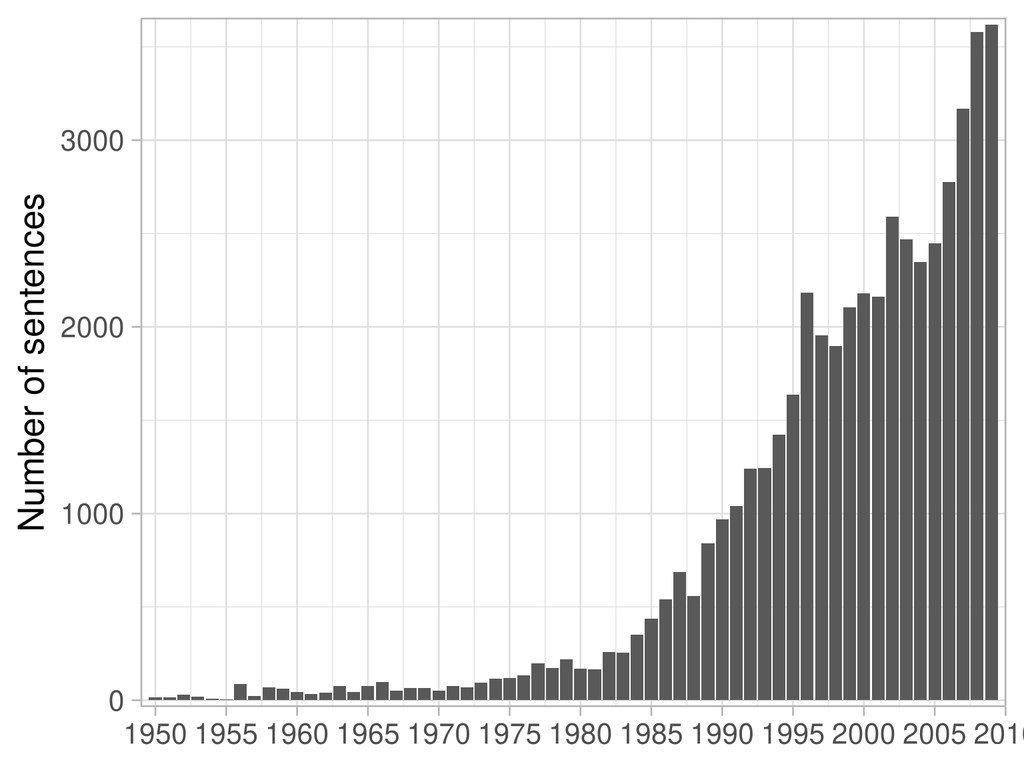

### Closest sentence from ‘rational’ and ‘rationality’ of the backbone community

| Sentence | Title | Year | Journal | Authors | Words Similarity |
| --- | --- | --- | --- | --- | --- |
| RECENT DEVELOPMENTS OF THE CONCEPT OF RATIONALITY The common knowledge discussions in the game theoretic literature have opened up new flexibility in modeling rational interaction, but have also raise… | [Game theory and the history of ideas about rationality: An Introductory Survey](https://doi.org/10.1017/S0266267100005137) | 1993 | Economics and Philosophy | Cudd A.E. | 0.825 |
| Thus, the bound on players’ rationality is more stringent in our paper than in most of the literature. | [Learning in Games by Random Sampling](https://doi.org/10.1006/jeth.2000.2694) | 2001 | Journal of Economic Theory | Friedman J. | 0.823 |
| The theorem states a relation between the rationality of the players and an equilibrium concept and supports the idea that the notion of rationality should not be restricted to expected utility maximi… | [Epistemic conditions for equilibrium in beliefs without independence](https://doi.org/10.1006/jeth.1996.0095) | 1996 | Journal of Economic Theory | Volij O. | 0.818 |
| Elhanan Ben Porath (1997) shows that several rounds of “continuation” are consistent with common certainty of rationality.2 Therefore, rationality alone does not imply the pessimistic and rather unpro… | [Field Centipedes](https://http://www.jstor.org/stable/25592522) | 2009 | The American Economic Review | Ignacio Palacios-Huerta, Oscar Volij | 0.811 |
| If rational players hypothesize a set of deviations Q(#) might occur from the equilibrium #, then each player ought rationally to respond to such deviations. | [Deviations, dynamics, and equilibrium refinements](https://doi.org/10.1006/jeth.1996.0001) | 1996 | Journal of Economic Theory | Rabin M. | 0.810 |
| Now, this line of bounded rationality research is intimately connected to the so-called non-cooperative, rational-choice, or classical game theory, in that a large part of its efforts are directed at … | [The legacy of Herbert Simon in game theory](https://doi.org/10.1016/j.jebo.2002.10.006) | 2004 | Journal of Economic Behavior and Organization | Sent E.M. | 0.809 |
| Decision theory and game theory may have failed to answer the normative question of what constitutes rational behaviour, but they have clarified some of the issues involved, and in the process obtaine… | [Rationality, Learning and Social Norms](https://http://www.jstor.org/stable/2235527) | 1996 | The Economic Journal | Abhinay Muthoo | 0.809 |
| the disposition to be rational if having the chance to act) is not enough to infer the truth of this counterfactual conditional, or to forecast beliefs after a deviation, which is a necessary conditio… | [What happened to the three-legged centipede game?](https://doi.org/10.1111/j.1467-6419.2008.00572.x) | 2009 | Journal of Economic Surveys | Kuechle G. | 0.804 |
| Individual rationality is an integral part of all game-theoretic models, both cooperative and non-cooperative. | [Taxes and subsidies in a polluting and politically powerful industry](https://doi.org/10.1016/j.asieco.2004.05.005) | 2004 | Journal of Asian Economics | Finkelshtain I. | 0.803 |
| By rationality of a player, the authors mean that the action actually chosen by that player maximizes his expected utility, given his beliefs at that state. | [Epistemic conditions for equilibrium in beliefs without independence](https://doi.org/10.1006/jeth.1996.0095) | 1996 | Journal of Economic Theory | Volij O. | 0.803 |
| They model the bounded rationality in two dimensions: the players differ in the level of precision with which they identify best responses as well as in their models of other players. | [An Empirical Model of Strategic Choice with an Application to Coordination Games](https://doi.org/10.1006/game.1998.0678) | 1999 | Games and Economic Behavior | Holt D.J. | 0.803 |
| Some of these may be eliminated by imposing a criterion of “rational” beliefs along the lines of the sequential equilibrium concept in [4]. | [Strategic Behavior in Dynamic Auctions](https://http://www.jstor.org/stable/25054717) | 1993 | Economic Theory | Ruqu Wang | 0.801 |
| INTRODUCTION Received game theory assumes that players are fully rational. | [Limited Foresight May Force Cooperation](https://http://www.jstor.org/stable/2695933) | 2001 | The Review of Economic Studies | Philippe Jehiel | 0.800 |
| We aim to establish criteria to determine if a probability belief of an agent is “rational.” | [On the Structure and Diversity of Rational Beliefs](https://http://www.jstor.org/stable/25054813) | 1994 | Economic Theory | Mordecai Kurz | 0.797 |
| Hence, each player can deduce that some actions are more risky than other actions, and a certain set of prior expectations can be defined as “rational.” | Risk dominance and coordination failures in static games | 1995 | Quarterly Review of Economics and Finance | Straub P.G. | 0.796 |
| We impose two weak constraints on the rationality function: (i) a move is not rational if there is another move that you believe would give you a better payoff; (ii) a move is rational if you believe … | [Grappling with the centipede: Defence of backward induction for bi-terminating games](https://doi.org/10.1017/S0266267100004958) | 1998 | Economics and Philosophy | Rabinowicz W. | 0.795 |
| In the following we describe a model of boundedly rational individuals playing this game. | [Sophisticated imitation in cyclic games](https://doi.org/10.1007/s001910000049) | 2000 | Journal of Evolutionary Economics | Hofbauer J. | 0.793 |
| If rationality is identified with maximizing expected utility, then we can define, in any model, the propositions that some particular player is rational, that all players are rational, that all playe… | [Knowledge, belief and counterfactual reasoning in games](https://doi.org/10.1017/S0266267100004132) | 1996 | Economics and Philosophy | Stalnaker R. | 0.793 |
| As long as it remains obscure how to characterize rational action in games, the rational expectations hypothesis, correctly applied, therefore leaves us as far from determinacy as ever. | [Expecting and Affecting](https://http://www.jstor.org/stable/2663333) | 1989 | Oxford Economic Papers | Michael Bacharach | 0.792 |
| In summary, we argue that there are two characteristics of players that need to be recognized in order to predict behavior when the assumption of common knowledge of rationality fails to hold. | [Depth of reasoning in strategic form games](https://doi.org/10.1016/j.socec.2005.12.003) | 2006 | Journal of Socio Economics | Ohtsubo Y. | 0.791 |
| The model of bounded rationality we study may seem somehow unnatural and isolated from classical problems of game theory. | How to play with a biased coin? | 2002 | Games and Economic Behavior | Gossner O. | 0.791 |
| (S6, Period 4) provide a general model of rationality by expressing a conjecture on players’ rational behaviour. | [Revealing the depth of reasoning in p-beauty contest games](https://doi.org/10.1007/s10683-006-9157-6) | 2008 | Experimental Economics | Sbriglia P. | 0.791 |
| In conventional game theory, related matters have inspired work on the implications of common belief of rationality; see e.g. | [Dynamic psychological games](https://doi.org/10.1016/j.jet.2008.01.004) | 2009 | Journal of Economic Theory | Battigalli P. | 0.791 |

### Closest sentences of the backbone community’s centroid

Sentence

Title

Year

Journal

Authors

Similarity to Backbone Centroid

There exists p > Pt such that in all equilibria P2- p Proposition 1 establishes that for a range of initial beliefs of player 1, the refined sequential equilibrium outcome is unique.

[A Bargaining Model with Incomplete Information](https://http://www.jstor.org/stable/2297933)

1992

The Review of Economic Studies

Sushil Bikhchandani

0.829

Instead, we outline a set of plausible assumptions about the preferences of each player for certain outcomes.

The WTO and China’s ban on foreign investment in telecommunication services: A game-theoretic analysis

2000

Telecommunications Policy

Mueller M.

0.827

In the remainder of the paper, equilibrium refers to strategies and beliefs that form a PBE and satisfy the intuitive criterion.

Optimal export policy in the presence of informational barriers to entry and imperfect competition

1999

Journal of International Economics

Raff H.

0.825

However in this literature the players do not choose their beliefs, but rather the players’ beliefs are derived in equilibrium where they are assumed to be correct.

Nash equilibrium when players account for the complexity of their forecasts

2003

Games and Economic Behavior

Eliaz K.

0.825

The point of the paper is to identify which outcomes are consistent with equilibrium play, and which are not.

The economics of favors

1999

Journal of Economic Behavior and Organization

Neilson W.S.

0.822

This assumption seems highly unrealistic, and it is dropped in this paper and replaced by the assumption that each player has a perception of the payoff function of each of the other players; these perceptions may be incorrect.

[The Determination of Subjective Characteristic Functions in Games with Misperceived Payoff Functions](https://http://www.jstor.org/stable/1905749)

1956

Econometrica

R. Duncan Luce, Ernest W. Adams

0.821

2. Since an individual’s payoff resulting from a given course of action depends crucially on the action or choices of others, in determining the reasonable belief one player holds about the other’s choice, a natural consistency requires that each player’s belief about the other player’s choice coincide with the actual choice the other player intends to make.

[Altruism versus Egoism in Human Behavior of Mixed Motives: An Experimental Study](https://http://www.jstor.org/stable/3487758)

2003

The American Journal of Economics and Sociology

Yung-An Hu, Day-Yang Liu

0.817

6An interesting paper in which a general definition of equilibrium in games is proposed which explicitly involves certain beliefs of the players is Kreps and Wilson (I 982a).

[Expectations and Reputations in Bargaining: An Experimental Study](https://http://www.jstor.org/stable/1808119)

1983

The American Economic Review

Alvin E. Roth, Francoise Schoumaker

0.816

3. One may even avoid the use of an equilibrium notion altogether and define the set T(GA, RG) of the possible outcomes of the game (GA, RR) by x e T(GA, R ) if and only if x = gA(UN) for some profile UN of rationalizable strategies in the sense of Bernheim (1984) and Pearce (1984), or a profile of cautiously rationalizable strategies in the sense of Pearce (1984).

[Individual Rights and Social Evaluation: A Conceptual Framework](https://http://www.jstor.org/stable/2663724)

1996

Oxford Economic Papers

Prasanta K. Pattanaik, Kotaro Suzumura†

0.815

In static or one-stage games, the limits of what rational players can accomplish with communication has been characterized by the concepts of correlated equilibrium, incentive compatibility, and the revelation principle (see Aumann [1], and Myerson [6, 7, 8]).2 In dynamic or multistage games, even without communication, the problem of characterizing rational behavior is much more complicated, because of difficulties in defining how a rational player should behave after observing an event that had zero probability.

[Multistage Games with Communication](https://http://www.jstor.org/stable/1913154)

1986

Econometrica

Roger B. Myerson

0.814

Instead of making assumptions about players’ higher order beliefs about payoffs, we make assumptions about the ex ante probabilities of payoffs and deduce the required properties of players’ higher order beliefs, which can then be used to characterize equilibria.

[The Robustness of Equilibria to Incomplete Information](https://http://www.jstor.org/stable/2171737)

1997

Econometrica

Atsushi Kajii, Stephen Morris

0.814

Our theory makes use of two classes of rationality postulates in the analysis of game situations.

[Bargaining and Conflict Situations in the Light of a New Approach to Game Theory](https://http://www.jstor.org/stable/1816287)

1965

The American Economic Review

John C. Harsanyi

0.813

ON THE RELATIONSHIP BETWEEN NASH AND RATIONAL EXPECTATIONS EQUILIBRIA The notion of a Nash equilibrium in the strategy space may be a natural way to extend the notion of a self-fulfilling equilibrium to situations in which agents have different beliefs.

[Market Anticipations, Rational Expectations, and Bayesian Analysis](https://http://www.jstor.org/stable/2526314)

1978

International Economic Review

Robert M. Townsend

0.811

This result serves as the Nash equilibrium of behavior for this situation.

[Do people trust too much or too little?](https://doi.org/10.1016/j.joep.2008.04.006)

2009

Journal of Economic Psychology

Fetchenhauer D.

0.810

This paper exposes these phenomena and how they effect basic game-theoretic reasoning.

[Program equilibrium](https://doi.org/10.1016/j.geb.2004.02.002)

2004

Games and Economic Behavior

Tennenholtz M.

0.810

Finally, we will show that by proposing a point different from the equilibrium strategies (A or D) player 1 will induce an outcome less desired by him.

[Endogenous Agenda Formation in Three-Person Committees](https://www.jstor.org/stable/10.2307/41105860)

1987

Social Choice and Welfare

F. Gasmi, J. S. Banks

0.810

### Closest sentences of each HDBSCAN cluster’s centroid composing the backbone community

| Sentence | Title | Year | Journal | Authors | Similarity to HDSBSCAN Centroid |
| --- | --- | --- | --- | --- | --- |
| It is possible to concoct ” games’” in which decisions inconsistent with this theory are likely to be observed,1 but it is probably fairer to test it against behaviour in business. | [Uncertainty, Probability and Potential Surprise](https://http://www.jstor.org/stable/2550727) | 1958 | Economica | Lucien Foldes | 0.722 |
| If it should appear that a large number of reasonable people will accept some decisions inconsistent with the particular rule that the authors propose, and if their reasons are not random or foolish, … | [Theory of the Reluctant Duelist](https://http://www.jstor.org/stable/1811911) | 1956 | The American Economic Review | Daniel Ellsberg | 0.713 |
| And it may be possible to set up a game in such sanitary fashion, with suppression of identity of players and of all contextual detail, that there is literally no other visible basis for concerting un… | [For the Abandonment of Symmetry in Game Theory](https://http://www.jstor.org/stable/1927448) | 1959 | The Review of Economics and Statistics | T. C. Schelling | 0.697 |
| What we have is at best a single necessary condition for the rationality of both players jointly; we have no sufficient condition, and no necessary condition that can be applied to a single player. | [For the Abandonment of Symmetry in Game Theory](https://http://www.jstor.org/stable/1927448) | 1959 | The Review of Economics and Statistics | T. C. Schelling | 0.693 |
| In brief, I argued that Zeuthen’s probability calculations and comparisons are irrelevant to a player for the purpose of his selecting a good strategy, a conclusion which follows whether or not ultima… | [Rejoinder on the Bargaining Problem](https://http://www.jstor.org/stable/1055708) | 1958 | Southern Economic Journal | Harvey M. Wagner | 0.683 |
| That is, the strategy must be chosen so that even under circumstances which yield for this strategy a regret not smaller than under any other circumstances, this regret is not larger than for any othe… | [Rational Behavior, Uncertain Prospects, and Measurable Utility](https://http://www.jstor.org/stable/1907264) | 1950 | Econometrica | Jacob Marschak | 0.681 |
| The rational player must address himself to the empirical question of how, in the particular context of his own game, two rational players might achieve tacit coordination of choices, if he is to find… | [For the Abandonment of Symmetry in Game Theory](https://http://www.jstor.org/stable/1927448) | 1959 | The Review of Economics and Statistics | T. C. Schelling | 0.679 |
| Luce and Raiffa have given a succinct postulate of “rational behavior” stating that given “two alternatives which give rise to outcomes, a player will choose the one which yields the more preferred ou… | [Recurrent Objections to the Minimax Strategy](https://http://www.jstor.org/stable/1925456) | 1959 | The Review of Economics and Statistics | Anthony Y. C. Koo | 0.668 |
| An elegant feature of the Nash-Zeuthen hypothesis is that it succeeds in deducing such a set of probabilities of acceptance from a very small number of assumptions and without resorting to interperson… | [A Theory of Bargaining with Interpersonal Comparisons of Utility](https://http://www.jstor.org/stable/1055700) | 1958 | Southern Economic Journal | Edward Coen | 0.667 |
| The contention rather is “that the typical problems of economic behavior become strictly identical with the mathematical notions of suitable games of strategy”1. | [Oligopolistic Indeterminacy](https://http://www.jstor.org/stable/40434383) | 1952 | Weltwirtschaftliches Archiv | Fritz Machlup | 0.667 |

| Sentence | Title | Year | Journal | Authors | Similarity to HDSBSCAN Centroid |
| --- | --- | --- | --- | --- | --- |
| Under our theory, a conflict in this second sense among rational players can arise only in the following cases: 1. | [Bargaining and Conflict Situations in the Light of a New Approach to Game Theory](https://http://www.jstor.org/stable/1816287) | 1965 | The American Economic Review | John C. Harsanyi | 0.727 |
| Our theory makes use of two classes of rationality postulates in the analysis of game situations. | [Bargaining and Conflict Situations in the Light of a New Approach to Game Theory](https://http://www.jstor.org/stable/1816287) | 1965 | The American Economic Review | John C. Harsanyi | 0.723 |
| Consequently the quantities q1 and q2 in (7.2) and (7.3) represent the two players’ risk limits, defined as the highest subjective probability of a conflict that the 4 We have shown in Harsanyi [7, p.… | [A General Theory of Rational Behavior in Game Situations](https://http://www.jstor.org/stable/1909772) | 1966 | Econometrica | John C. Harsanyi | 0.695 |
| our rationality postulates yield a decision rule identical to a decision rule for bargaining behavior first proposed by Zeuthen [20], which we call “Zeuthen’s principle.” | [Bargaining and Conflict Situations in the Light of a New Approach to Game Theory](https://http://www.jstor.org/stable/1816287) | 1965 | The American Economic Review | John C. Harsanyi | 0.687 |
| e have already mentioned that classical economic theory fails to furnish determinate predictions in game situations, at least in those where there is siginificant strategical interdependence between t… | [Bargaining and Conflict Situations in the Light of a New Approach to Game Theory](https://http://www.jstor.org/stable/1816287) | 1965 | The American Economic Review | John C. Harsanyi | 0.685 |
| In this case it is clear that, although the two games have the same monetary expected value, a reasonable man will not be indifferent between the games, if he is more fearful of losing money than he i… | [An Introduction to Bernoullian Utility Theory: I. Utility Functions](https://http://www.jstor.org/stable/3439089) | 1967 | The Swedish Journal of Economics | Niels Erik Jensen | 0.684 |
| We shall now try to indicate, as far as possible within the space available, how our rationality postulates can actually be used for defining rational behavior in specific game situati | [A General Theory of Rational Behavior in Game Situations](https://http://www.jstor.org/stable/1909772) | 1966 | Econometrica | John C. Harsanyi | 0.679 |
| Yet there can be little doubt about the great analytical advantages that will accrue from a general theory of rational behavior in game situations, based on a satisfactory concept of rationality and y… | [A General Theory of Rational Behavior in Game Situations](https://http://www.jstor.org/stable/1909772) | 1966 | Econometrica | John C. Harsanyi | 0.679 |
| This line of development is initiated by the works of Shapley (“stochastic games”) and Everett (“recursive games”).3 Within the general scope of games in extensive form, it would be profitable to repl… | [On the Applicability of Game Theory in Economics: A Survey](https://http://www.jstor.org/stable/3438941) | 1966 | The Swedish Journal of Economics | Jan Odhnoff | 0.679 |
| One immediate result of the game theoretic formulation of a decision process in extensive form [18] was that it highlighted the paradox concerning rational behavior and complete information; thus theo… | [Simulation of the Industry and The Firm](https://http://www.jstor.org/stable/1810952) | 1960 | The American Economic Review | Martin Shubik | 0.676 |

| Sentence | Title | Year | Journal | Authors | Similarity to HDSBSCAN Centroid |
| --- | --- | --- | --- | --- | --- |
| Given Assumptions 1, 2, 3 and 4, it follows that an admissible representation of the agent’s preferences is (2) U(X)= U E (Xs) where U is an increasing function of its argument. | [A Homiletic Exposition of the Expected Utility Hypothesis](https://http://www.jstor.org/stable/2553568) | 1977 | Economica | Charles Blackorby, Russell Davidson, David Donaldson | 0.699 |
| Clearly a method of social choice which required compiete information on every agent’s preferences for all conceivable states would not be institutionally or operationally viable, and some information… | A dynamical model of political equilibrium | 1977 | Journal of Economic Theory | Kramer G. | 0.688 |
| The following theorem formalizes the absolute advantage of less conservative agents. | [Equilibrium and Agency–Inadmissible Agents in the Public Agency Problem](https://http://www.jstor.org/stable/1801664) | 1979 | The American Economic Review | Stephen A. Ross | 0.683 |
| In our case, decision have to be made exante and agents are not assumed to have either a priori probabilities or a preference relation from which subjective probabilities can be inferred. | [Competitive Analysis under Complete Ignorance](https://http://www.jstor.org/stable/2525896) | 1975 | International Economic Review | Elisha A. Pazner, David Schmeidler | 0.681 |
| As already suggested, it may be possible to construct direct mechanisms for which, even if truthfulness is not a dominant strategy, it is at least an expected utility maximizing or a maximin strategy … | [The Implementation of Social Choice Rules: Some General Results on Incentive Compatibility](https://http://www.jstor.org/stable/2297045) | 1979 | The Review of Economic Studies | Partha Dasgupta, Peter Hammond, Eric Maskin | 0.677 |
| When no assumptions are made on the preference of the agents being not ” too dissimilar “, we get weaker approximate notions. | [Some Equivalence Theorems](https://http://www.jstor.org/stable/2296705) | 1974 | The Review of Economic Studies | M. Ali Khan | 0.673 |
| If an agent’s preferences are “harmonious”, or “dynamically consistent” (Hammond, 1976), then his dynamic choices will be consistent with the metastatic choice of a single intertemporal plan. | [Dynamic Restrictions on Metastatic Choice](https://http://www.jstor.org/stable/2553567) | 1977 | Economica | Peter J. Hammond | 0.672 |
| There may be other-counteracting or dominating-kinds of incentives present as well which would produce a net result of revealed preferences. | [Estimating Willingness to Pay: Why and How?](https://http://www.jstor.org/stable/3439956) | 1979 | The Scandinavian Journal of Economics | Peter Bohm | 0.672 |
| In addition, it can be seen that the sufficiency result is not robust to the introduction of asymmetry among informed agents. | Information, futures prices, and stabilizing speculation | 1978 | Journal of Economic Theory | Danthine J. | 0.669 |
| Up to this point homogeneous beliefs are assumed, but in Section 6 this assumption is relaxed to the extent that we allow the agent to be more informed at the time he chooses his action. | [Moral Hazard and Observability](https://www.jstor.org/stable/10.2307/3003320) | 1979 | The Bell Journal of Economics | Bengt Holmström | 0.667 |

| Sentence | Title | Year | Journal | Authors | Similarity to HDSBSCAN Centroid |
| --- | --- | --- | --- | --- | --- |
| In addition, there appear to be similarities between the rational-expectations approach in this game setting and the approach taken by Shefrin [9] and Sanghvi and Sobel [8] in somewhat different game … | [Sequences of Games with Varying Opponents](https://http://www.jstor.org/stable/1914005) | 1979 | Econometrica | R. W. Rosenthal | 0.703 |
| While the theory of games reveals the potential richness of behavior when rational individuals are faced with conflict of interest, the capability of reacting to each other’s actions (or expected acti… | [Rationality as Process and as Product of Thought](https://http://www.jstor.org/stable/1816653) | 1978 | The American Economic Review | Herbert A. Simon | 0.694 |
| Their results imply that with the exception of two situations every member’s choice of an optimal strategy always depends on his beliefs concerning other members’ preferences. | [On Preferences, Beliefs, and Manipulation within Voting Situations](https://http://www.jstor.org/stable/1912678) | 1977 | Econometrica | Jean-Marie Blin, Mark A. Satterthwaite | 0.694 |
| ON THE RELATIONSHIP BETWEEN NASH AND RATIONAL EXPECTATIONS EQUILIBRIA The notion of a Nash equilibrium in the strategy space may be a natural way to extend the notion of a self-fulfilling equilibrium … | [Market Anticipations, Rational Expectations, and Bayesian Analysis](https://http://www.jstor.org/stable/2526314) | 1978 | International Economic Review | Robert M. Townsend | 0.694 |
| is in no way immune to the possibility of strategic behavior by respondents. | The valuation of aesthetic preferences | 1976 | Journal of Environmental Economics and Management | Brookshire D. | 0.693 |
| In section V, a paradoxical consequence of the players’ “rationality” will be discussed. | [Unanimity in the Supreme Court: A Game-Theoretic Explanation of the Decision in the White House Tapes Case](https://http://www.jstor.org/stable/30022994) | 1977 | Public Choice | Steven J. Brams, Douglas Muzzio | 0.689 |
| Our main purpose will be to present a more general concept of decisiveness and to show that this notion allows us to characterize broad classes of games and social choice procedures. | Representations of binary decision rules by generalized decisiveness structures | 1979 | Journal of Economic Theory | Ferejohn J. | 0.684 |
| Another point we must not leave out of consideration is the fact that the automatic forces of the economic mechanism lead to correct results only if the rules of the game on which this automatic actio… | [The Origins of Contradictions in Our Economy and the Path to Their Solution](https://http://www.jstor.org/stable/4379411) | 1970 | Eastern European Economics | Ferenc Jánossy, Czaba L. Köhalmi | 0.683 |
| They suggested that situations in which some will gain and some will lose be transformed into a “game” in which the general payoff distribution is known but the specific payoff to each individual is n… | [Probabilistic Compensation Criteria](https://http://www.jstor.org/stable/1880801) | 1972 | The Quarterly Journal of Economics | A. Mitchell Polinsky | 0.680 |
| This is just one example of the application of limited rationality to the analysis of games. | [A Note on the Hicks Theory of Strike Bargaining](https://http://www.jstor.org/stable/40749957) | 1977 | Zeitschrift für die gesamte Staatswissenschaft / Journal of Institutional and Theoretical Economics | PETER RICE | 0.678 |

| Sentence | Title | Year | Journal | Authors | Similarity to HDSBSCAN Centroid |
| --- | --- | --- | --- | --- | --- |
| Theorem 1 and the existence of stable outcomes are unchanged when agents are indifferent between some alternatives, but we will see in Sec. | [The Evolution of the Labor Market for Medical Interns and Residents: A Case Study in Game Theory](https://http://www.jstor.org/stable/1831989) | 1984 | Journal of Political Economy | Alvin E. Roth | 0.713 |
| If, on the other hand, we suppose that agents have complete knowledge of each other’s preferences, the applicability of the results is greatly reduced. | [The Manipulability of Resource Allocation Mechanisms](https://http://www.jstor.org/stable/2297433) | 1984 | The Review of Economic Studies | William Thomson | 0.702 |
| Given more than one optimal alternative, each agent chooses a specific one if induced to do so by others. | Land speculation and the rental price of housing | 1983 | Journal of Urban Economics | Eckart W. | 0.701 |
| Moreover, a simple condition on the rules by which agents choose actions based on their current beliefs, satisfied by many apphcations of interest, suffices to rule out agreeing to disagree. | Learning to agree | 1983 | Economics Letters | Cave J. | 0.700 |
| As discussed earlier, an agent’s observed decision in any period t is not assumed to always equal its optimal choice in that period. | The origin of predictable dynamic behavior | 1989 | Journal of Economic Behavior and Organization | Heiner R. | 0.699 |
| We further demonstrate that a rational agent will not gather information purely for the sake of reducing prior uncertainty, nor will he find it worthwhile to use his resources to completely eliminate … | Investment in information acquisition | 1985 | Economics Letters | Danthine J. | 0.694 |
| To test the general idea that preferences are reasonable only if they are represented by a utility function, we suppose finally that this agent’s preferences are represented by a utility function. | [Utility theory and the Bayesian paradigm](https://doi.org/10.1007/BF00134109) | 1989 | Theory and Decision | Sobel J. | 0.694 |
| Second, the authors essentially point out for their two-state example that although the structure of the first-best contract described in Proposition 1 does not depend upon the principal’s beliefs, th… | Limited liability contracts between principal and agent | 1983 | Journal of Economic Theory | Sappington D. | 0.693 |
| In Section 5, we show that, without communication it cannot be common knowledge that the individuals would unanimously approve a change from a decision rule that is incentive efficient, as defined in … | [Efficient and Durable Decision Rules with Incomplete Information](https://http://www.jstor.org/stable/1912117) | 1983 | Econometrica | Bengt Holmström, Roger B. Myerson | 0.692 |
| This implication can be avoided by making the preferences of the agent stochastic (compare LUCAS [1980]). | [On the Efficacy of Fiscal Policy](https://http://www.jstor.org/stable/20075620) | 1986 | Annales d’Économie et de Statistique | Jürgen Eichberger | 0.691 |

| Sentence | Title | Year | Journal | Authors | Similarity to HDSBSCAN Centroid |
| --- | --- | --- | --- | --- | --- |
| 2 Several authors have recently pointed out that these prescriptions are particularly sensitive to small variations in the description of the game for certain situations in which the standard equilibr… | A positive approach to non-cooperative games | 1986 | Journal of Economic Behavior and Organization | Friedman J. | 0.695 |
| However in general the expectation that a Nash equilibrium will result is not the only expectation that is consistent with the available information (cognitive aspect)17. | [Individualistic Foundation for General Equilibrium Theory: a Review of some Game Theoretic Approaches](https://http://www.jstor.org/stable/40723904) | 1989 | Recherches Économiques de Louvain / Louvain Economic Review | Maarten C. W. JANSSEN | 0.691 |
| Such an application may be supported without assumptions on the players’ rationality and, more specifically, without assuming that any of them “computed” the equilibrium. | Nash and correlated equilibria: Some complexity considerations | 1989 | Games and Economic Behavior | Gilboa I. | 0.677 |
| This extreme hypothetical suggests more generally that the salience of Nash equilibrium may provide a landmark around which common expectations can form. | [Rationalizable Strategic Behavior](https://http://www.jstor.org/stable/1911196) | 1984 | Econometrica | B. Douglas Bernheim | 0.676 |
| These studies have demonstrated some dimensions in which standard predictions of both axiomatic and strategic models are systematically nondescriptive of observed behavior. | [A Note on Risk Aversion in a Perfect Equilibrium Model of Bargaining](https://http://www.jstor.org/stable/1911733) | 1985 | Econometrica | Alvin E. Roth | 0.675 |
| This statement also seems relevant to models developed within the frameworks other than game theory. | [Representing the negotiation process with a rule-based formalism](https://doi.org/10.1007/BF00133164) | 1988 | Theory and Decision | Kersten G.E. | 0.674 |
| If the order in which the players respond to a non-equilibrium point and the information available to them at the time of their computation are not predetermined, then the notion of a stable equilibri… | Asynchronous algorithms in non-cooperative games | 1988 | Journal of Economic Dynamics and Control | Başar T. | 0.669 |
| While this statement may appear somewhat contentious to the economist, it has long been known to the game-theorist. | Reorganization in bankruptcy and the issue of strategic risk | 1983 | Journal of Banking and Finance | Aivazian V. | 0.667 |
| This assumption is troublesome, and without it, a pure strategy equilibrium may not exist. | [Retail Pricing and Clearance Sales](https://http://www.jstor.org/stable/1804124) | 1986 | The American Economic Review | Edward P. Lazear | 0.667 |
| And in the absence of a theory about how agents select an equilibrium in the game with complete or incomplete information defined by a mechanism, one should require that the set of Nash or Bayesian eq… | [Implementation in Dominant Strategies under Complete and Incomplete Information](https://http://www.jstor.org/stable/2297618) | 1985 | The Review of Economic Studies | Rafael Repullo | 0.665 |

| Sentence | Title | Year | Journal | Authors | Similarity to HDSBSCAN Centroid |
| --- | --- | --- | --- | --- | --- |
| Such an equilibrium can be supported by beliefs that satisfy an assumption analogous to (A2). | [Strategic Delay in Bargaining](https://http://www.jstor.org/stable/2297563) | 1987 | The Review of Economic Studies | Anat R. Admati, Motty Perry | 0.755 |
| One other possible extension involves the equilibrium assumption made. | On practicing the art of modeling: The guaranteed student loan program | 1982 | Socio Economic Planning Sciences | Bayus B. | 0.741 |
| However, it is shown in the appendix that any other set of out-of-equilibrium beliefs will generate another equilibrium which is equivalent in terms of observable behavior. | [Equilibrium Verification and Reporting Policies in a Model of Tax Compliance](https://http://www.jstor.org/stable/2526692) | 1986 | International Economic Review | Jennifer F. Reinganum, Louis L. Wilde | 0.738 |
| Some sequential equilibria are supported by beliefs that the analyst can reject because they are supported by beliefs that are implausible. | [Sequential Equilibria](https://http://www.jstor.org/stable/1912767) | 1982 | Econometrica | David M. Kreps, Robert Wilson | 0.734 |
| We fixed a particular equilibrium outcome, and we restricted B’s out-of-equilibrium beliefs by giving and applying a criterion for saying that a particular outof-equilibrium message was “unreasonable”… | [Signaling Games and Stable Equilibria](https://http://www.jstor.org/stable/1885060) | 1987 | The Quarterly Journal of Economics | In-Koo Cho, David M. Kreps | 0.724 |
| If such results are deemed “desirable,” the normative aspect of equilibrium reappears. | [On Equilibrium](https://http://www.jstor.org/stable/4537808) | 1983 | Journal of Post Keynesian Economics | John F. Henry | 0.723 |
| In this case the intuitive criterion allows arbitrary beliefs to support the equilibrium. | [Financial Signalling and the “Deep-Pocket” Argument](https://http://www.jstor.org/stable/2555649) | 1989 | The RAND Journal of Economics | Michel Poitevin | 0.713 |
| Hence, the equilibrium beliefs supporting the equilibrium in Proposition can sometimes be given a systematic foundation. | [Umbrella Branding as a Signal of New Product Quality: An Example of Signalling by Posting a Bond](https://http://www.jstor.org/stable/2555667) | 1988 | The RAND Journal of Economics | Birger Wernerfelt | 0.710 |
| Moreover, while equilibrium beliefs are structurally consistent in some cases, the alternative conjectures that justify them are inconsistent with the hypothesis (implicit in sequential rationality) t… | [Structural Consistency, Consistency, and Sequential Rationality](https://http://www.jstor.org/stable/1913559) | 1987 | Econometrica | David M. Kreps, Garey Ramey | 0.708 |
| We find it helpful to pose formally a criterion for updating beliefs that need not distinguish a priori between moves along the proposed equilibrium and other moves. | Perfect sequential equilibrium | 1986 | Journal of Economic Theory | Grossman S. | 0.706 |

| Sentence | Title | Year | Journal | Authors | Similarity to HDSBSCAN Centroid |
| --- | --- | --- | --- | --- | --- |
| Hence, I believe that simple games such as the ones presented here should serve as useful complements to rather than as substitute for the richer but less transparent rational expectations models. | Simple games of market manipulation | 1989 | Economics Letters | Vila J.L. | 0.761 |
| As long as it remains obscure how to characterize rational action in games, the rational expectations hypothesis, correctly applied, therefore leaves us as far from determinacy as ever. | [Expecting and Affecting](https://http://www.jstor.org/stable/2663333) | 1989 | Oxford Economic Papers | Michael Bacharach | 0.746 |
| If one further adopts the hypothesis of rational expectations’1* then it is assumed that players behave as if they knew the rules of the game. | [FORECASTING AND ECONOMIC POLICY](https://http://www.jstor.org/stable/23875452) | 1982 | National Institute Economic Review | David G. Mayes | 0.737 |
| 8 It states that every individually rational outcome can be supported by some equilibrium strategy (see for example FUDENBERG and MASKIN [1986]). | [Entry, Sunk Costs and Renegotiation in Duopoly](https://http://www.jstor.org/stable/20075756) | 1989 | Annales d’Économie et de Statistique | James Bergin, W. Bentley Macleod | 0.735 |
| Radner [1980] allows players to be subject to bounded rationality constraints while Kreps, Milgrom, Roberts and Wilson [1982] assume players are rational but that it is not common knowledge. | [Collusion in Multiproduct Oligopoly Games under a Finite Horizon](https://http://www.jstor.org/stable/2526856) | 1987 | International Economic Review | Joseph E. Harrington, Jr. | 0.701 |
| It turns out that the strategy restriction may impose a kind of “bounded rationality” on players in the sense that expectations used to calculate optimal (equilibrium) decisions need not be confirmed … | [Differentiable Nash Equilibria in Altruistic Economies](https://http://www.jstor.org/stable/41796288) | 1984 | Zeitschrift für Nationalökonomie / Journal of Economics | John Lane, Wolfgang Leininger | 0.696 |
| Alternative routes to rationalizability are considered in Section 4, where it is shown that several plausible modes of boundedly rational behavior will lead to strategic choices which are, in some sen… | [Rationalizable Strategic Behavior](https://http://www.jstor.org/stable/1911196) | 1984 | Econometrica | B. Douglas Bernheim | 0.692 |
| In static or one-stage games, the limits of what rational players can accomplish with communication has been characterized by the concepts of correlated equilibrium, incentive compatibility, and the r… | [Multistage Games with Communication](https://http://www.jstor.org/stable/1913154) | 1986 | Econometrica | Roger B. Myerson | 0.692 |
| Some conditions are stipulated for rational decisions, and it is demonstrated that, provided that the equilibrium is unique, decisions in accordance with the Nash noncooperative equilibrium concept sa… | [On the Status of the Nash Type of Noncooperative Equilibrium in Economic Theory](https://http://www.jstor.org/stable/3439426) | 1982 | The Scandinavian Journal of Economics | Leif Johansen | 0.692 |
| Regardless of whether or not one believes that the generalized Cournot process reflects plausible behavior, stability under this process is essential for establishing that Nash behavior is the unique … | [Rationalizable Strategic Behavior](https://http://www.jstor.org/stable/1911196) | 1984 | Econometrica | B. Douglas Bernheim | 0.690 |

[output not shown]

| Sentence | Title | Year | Journal | Authors | Similarity to HDSBSCAN Centroid |
| --- | --- | --- | --- | --- | --- |
| In this context, the class of equilibria identified in Theorem 1 points to a concrete example in which rational decision makers update their beliefs by conditioning on non- partitional information str… | [News Management and the Value of Firms](https://http://www.jstor.org/stable/2555853) | 1994 | The RAND Journal of Economics | H. S. Shin | 0.742 |
| In other words, beliefs about out-of-equilibrium selections must be specified as well. | Communication requirements and strategic mechanisms for market organization | 1991 | Journal of Mathematical Economics | Chakravorti B. | 0.740 |
| Therefore we will examine whether and when pooling equilibria with intuitive beliefs exist. | Limit pricing when incumbents have conflicting interests | 1999 | International Journal of Industrial Organization | Schultz C. | 0.720 |
| To trim the set of equilibrium outcomes, we rely on the suggestions of Cho and Kreps (1987) to restrict the out-of-equilibrium beliefs described in Condition 3(c). | Receiver discretion in signalling models: Information transmission to competing retailers | 1998 | International Journal of Industrial Organization | Albæk S. | 0.718 |
| Necessary conditions for a pooling equilibrium are that both an α H-type and an α M-type increase utility by mimicking an α L-type given the above posterior beliefs. | Towards an economic theory of party ideology | 1998 | European Journal of Political Economy | Swank O.H. | 0.718 |
| Representing beliefs by general non-additive probabilities weakens the restrictions imposed on behaviour by equilibrium consistency requirements. | [E-capacities and the ellsberg paradox](https://doi.org/10.1023/a:1004994630014) | 1999 | Theory and Decision | Eichberger J. | 0.714 |
| This paper takes an opposite tack in assigning beliefs off the equilibrium path. | [Uncertainty and Delay in Bargaining](https://http://www.jstor.org/stable/2298087) | 1990 | The Review of Economic Studies | In-Koo Cho | 0.713 |
| We require that sensible beliefs should rule out a type for which a deviation is equilibrium dominated as long as the deviation is not dominated for the other type, and this allows us to define the no… | Receiver discretion in signalling models: Information transmission to competing retailers | 1998 | International Journal of Industrial Organization | Albæk S. | 0.712 |
| Following Gertner, Gibbons, and Scharfstein (1988), I now consider a restriction on beliefs based on the refinement of perfect sequential equilibrium proposed by Grossman and Perry (1986). | [Multidimensional Signalling and Diversification](https://http://www.jstor.org/stable/2555946) | 1997 | The RAND Journal of Economics | Yongmin Chen | 0.708 |
| This restriction requires that beliefs following an out-of-equilibrium move be what Fudenberg and Tirole (1991) term ‘reasonable’ beliefs. | [Repeated Signalling Games and Dynamic Trading Relationships](https://http://www.jstor.org/stable/2527293) | 1998 | International Economic Review | Daniel R. Vincent | 0.707 |

| Sentence | Title | Year | Journal | Authors | Similarity to HDSBSCAN Centroid |
| --- | --- | --- | --- | --- | --- |
| For instance, the paper assumes many exogenous restrictions on the beliefs and the probability assessments of players to obtain the equilibrium. | Corporate governance and board effectiveness | 1998 | Journal of Banking and Finance | John K. | 0.749 |
| In the remainder of the paper, equilibrium refers to strategies and beliefs that form a PBE and satisfy the intuitive criterion. | Optimal export policy in the presence of informational barriers to entry and imperfect competition | 1999 | Journal of International Economics | Raff H. | 0.743 |
| The variation of beliefs, ,u, in the current period is not assumed to affect future play of the game.12 10 This definition does not require pure strategies but (i) as long as Al is satisfied, the equi… | [Repeated Signalling Games and Dynamic Trading Relationships](https://http://www.jstor.org/stable/2527293) | 1998 | International Economic Review | Daniel R. Vincent | 0.733 |
| Fudenberg and Levine (1993a)propose the notion of self-confirming equilibrium, in which players think, to the best of their knowledge, that they could not have profitably deviated. | Equilibrium and reinforcement learning in private-information games: An experimental study | 1999 | Journal of Economic Dynamics and Control | Feltovich N. | 0.723 |
| Second, it postulates a Bayesian-Nash behavior between the agents. | [Collusion Under Asymmetric Information](https://http://www.jstor.org/stable/2171943) | 1997 | Econometrica | Jean-Jacques Laffont, David Martimort | 0.718 |
| There exists p > Pt such that in all equilibria P2- p Proposition 1 establishes that for a range of initial beliefs of player 1, the refined sequential equilibrium outcome is unique. | [A Bargaining Model with Incomplete Information](https://http://www.jstor.org/stable/2297933) | 1992 | The Review of Economic Studies | Sushil Bikhchandani | 0.717 |
| Instead of making assumptions about players’ higher order beliefs about payoffs, we make assumptions about the ex ante probabilities of payoffs and deduce the required properties of players’ higher or… | [The Robustness of Equilibria to Incomplete Information](https://http://www.jstor.org/stable/2171737) | 1997 | Econometrica | Atsushi Kajii, Stephen Morris | 0.711 |
| The solution concept is perfect Bayesian equilibrium, introducing the intuitive criterion (Cho and Kreps, 1987) to restrict out-of-equilibrium beliefs. | Political stabilization cycles in high-inflation economies | 1998 | Journal of Development Economics | Stein E. | 0.710 |
| The present paper shows that these restrictions on players’ beliefs are better understood by connecting them to the principle that different players choose their strategies independently. | [Strategic independence and perfect Bayesian equilibria](https://doi.org/10.1006/jeth.1996.0082) | 1996 | Journal of Economic Theory | Battigalli P. | 0.709 |
| For instance, suppose that each player begins deliberations with the prior probability distribution 0 k s With endogenous correlation, as in the Vanderschraaf equilibrium concept, the payoff that a pl… | [Joint beliefs in conflictual coordination games](https://doi.org/10.1023/A:1004962809537) | 1997 | Theory and Decision | Vanderschraaf P. | 0.708 |

| Sentence | Title | Year | Journal | Authors | Similarity to HDSBSCAN Centroid |
| --- | --- | --- | --- | --- | --- |
| In a cautious equilibrium, players do not necessarily know the rationality of opponents, but they view rationality as infinitely more likely than irrationality. | [Nash Equilibrium without Mutual Knowledge of Rationality](https://http://www.jstor.org/stable/25055241) | 1999 | Economic Theory | Kin Chung Lo | 0.765 |
| If rational players hypothesize a set of deviations Q(#) might occur from the equilibrium #, then each player ought rationally to respond to such deviations. | [Deviations, dynamics, and equilibrium refinements](https://doi.org/10.1006/jeth.1996.0001) | 1996 | Journal of Economic Theory | Rabin M. | 0.761 |
| They model the bounded rationality in two dimensions: the players differ in the level of precision with which they identify best responses as well as in their models of other players. | [An Empirical Model of Strategic Choice with an Application to Coordination Games](https://doi.org/10.1006/game.1998.0678) | 1999 | Games and Economic Behavior | Holt D.J. | 0.760 |
| The implication is that the strategic behavior of informed rational players may entail the choice of non-Nash strategies. | [Strong Rationalizability for Two-Player Noncooperative Games](https://http://www.jstor.org/stable/25055154) | 1999 | Economic Theory | Niels Anthonisen | 0.748 |
| Thus, the hypothesis of rational expectations seems implausible except in games that repeated many times, or where players in a «one-shot» game have reason to believe that they all play strategies app… | [RATIONALITY IN ECONOMICS](https://www.jstor.org/stable/10.2307/41623954) | 1997 | Rivista Internazionale di Scienze Sociali | PETER J. HAMMOND | 0.745 |
| The question now arises of whether player rationality can be assumed to be common knowledge if rationality is modelled as the avoidance of weakly dominated acts, or (formulating this alternatively) ex… | [Impossibility theorems for normal form games](https://doi.org/10.1023/A:1004968625637) | 1998 | Theory and Decision | Squires D. | 0.744 |
| Gul (1991) considers two kinds of consistent restrictions about the beliefs of strategically rational players: (i) restrictions on beliefs about the behavior of “nonrational” types and (ii) restrictio… | [Strategic rationality orderings and the best rationalization principle](https://doi.org/10.1006/game.1996.0033) | 1996 | Games and Economic Behavior | Battigalli P. | 0.741 |
| Our formulation captures what the players might rationally choose in response if they come to believe the proposed deviation, and only the proposed deviation, is likely. | [Deviations, dynamics, and equilibrium refinements](https://doi.org/10.1006/jeth.1996.0001) | 1996 | Journal of Economic Theory | Rabin M. | 0.737 |
| At the core of this model is the assumption that players are boundedly rational, gradually responding to the observed history of play rather than immediately leaping to equilibrium. | [Signalling and Adaptive Learning in an Entry Limit Pricing Game](https://http://www.jstor.org/stable/2555781) | 1997 | The RAND Journal of Economics | David J. Cooper, Susan Garvin, John H. Kagel | 0.736 |
| RECENT DEVELOPMENTS OF THE CONCEPT OF RATIONALITY The common knowledge discussions in the game theoretic literature have opened up new flexibility in modeling rational interaction, but have also raise… | [Game theory and the history of ideas about rationality: An Introductory Survey](https://doi.org/10.1017/S0266267100005137) | 1993 | Economics and Philosophy | Cudd A.E. | 0.731 |

| Sentence | Title | Year | Journal | Authors | Similarity to HDSBSCAN Centroid |
| --- | --- | --- | --- | --- | --- |
| In an expanded version of this paper, some plausible restrictions of these beliefs are formalized in a ‘Strong Intuitive Criterion’ [a somewhat stronger criterion than the ‘Intuitive Criterion’] and s… | Investment and government intervention in credit markets when there is asymmetric information | 1991 | Journal of Public Economics | Innes R. | 0.773 |
| We will not want to base our Assumption 1 on restrictions of an expected utility function of every agent. | [Market Demand Functions in the Capital Asset Pricing Model](https://doi.org/10.1006/jeth.1997.2370) | 1998 | Journal of Economic Theory | Bottazzi J.M. | 0.754 |
| They show that this result can be overturned by changing the assumptions about agents’ prior beliefs. | [Public and Private Information about Short- and Long-Lived Assets](https://http://www.jstor.org/stable/2527020) | 1990 | International Economic Review | Jeremy R. Rudin | 0.751 |
| On one view the actual choice of the agent may be the fundamental reality, and the preference strengths or probabilistic dispositions to choose no more than an estimation or an accounting of them. | [Prudence and extensionality in theories of preference and value](https://doi.org/10.1007/BF01082055) | 1995 | Theory and Decision | Vickers J. | 0.750 |
| In the example analyzed above, we have assumed somewhat extreme preferences of the agents, and one might wonder whether our propositions do not rely heavily on this assumption. | Comparative advantage under oligopoly | 1997 | Journal of International Economics | Cordella T. | 0.749 |
| We aim to establish criteria to determine if a probability belief of an agent is “rational.” | [On the Structure and Diversity of Rational Beliefs](https://http://www.jstor.org/stable/25054813) | 1994 | Economic Theory | Mordecai Kurz | 0.744 |
| Since agents do not have perfect information about the use and utility of a particular resource, we make a distinction between the actual payoffs, Gr(fr), that agents receive when they access them, an… | Computation as economics | 1998 | Journal of Economic Dynamics and Control | Huberman B.A. | 0.743 |
| The theoretical underpinnings of this assumption are found in Aumann’s (1976) seminal work, which shows that, under the assumptions of common knowledge of rationality and common priors, two rational e… | [Differential Interpretation of Information in Inflation Forecasts](https://http://www.jstor.org/stable/2646860) | 1999 | The Review of Economics and Statistics | Eugene Kandel, Ben-Zion Zilberfarb | 0.741 |
| Agents differ in their preferences on the optimal decision. | Social learning with case-based decisions | 1999 | Journal of Economic Behavior and Organization | Blonski M. | 0.740 |
| Agents differ in their preferences on the optimal decision. | Social learning with case-based decisions | 1999 | Journal of Economic Behavior and Organization | Blonski M. | 0.740 |

| Sentence | Title | Year | Journal | Authors | Similarity to HDSBSCAN Centroid |
| --- | --- | --- | --- | --- | --- |
| This Nash equilibrium result, and more general issues of decision making, are discussed in Sections 7 and 8. | [Inductive game theory: A basic scenario](https://doi.org/10.1016/j.jmateco.2008.07.009) | 2008 | Journal of Mathematical Economics | Kaneko M. | 0.810 |
| Our formulation of the equilibrium condition is somewhat unusual, but it is evident that our definition of Nash equilibrium is standard: expected utility maximization is equivalent to assigning zero p… | [On the Generic Finiteness of Equilibrium Outcome Distributions in Game Forms](https://http://www.jstor.org/stable/2692238) | 2001 | Econometrica | Srihari Govindan, Andrew McLennan | 0.793 |
| A major branch of this literature considers Nash-based equilibrium concepts. | Migration-proof Tiebout equilibrium: Existence and asymptomatic efficiency | 2002 | Journal of Public Economics | Conley J. | 0.792 |
| Doubt was cast on whether uniqueness of Nash equilibrium can be proven under more general conditions. | [Uniqueness and comparative statics of Nash equilibrium in a tariff retaliation model](https://http://www.jstor.org/stable/41795605) | 2009 | Journal of Economics | Siu-kee Wong | 0.788 |
| We next present an equilibrium concept somewhat different from the standard Nash equilibrium of a game. | [Morale and the evolution of norms](https://doi.org/10.1016/j.socec.2005.11.029) | 2007 | Journal of Socio Economics | Teraji S. | 0.786 |
| Equilibrium concepts presume that players’ strategy choices are an equilibrium point in the sense of Nash (1950). | [Uniqueness conditions for strongly point-rationalizable solutions to games with metrizable strategy sets](https://doi.org/10.1016/j.jmateco.2006.01.001) | 2006 | Journal of Mathematical Economics | Zimper A. | 0.784 |
| well known that this consideration diseapears at (pure strategy) equilibrium. | [Interpretation of electoral mixed strategies](https://www.jstor.org/stable/10.2307/41106357) | 2000 | Social Choice and Welfare | Jean-François Laslier | 0.780 |
| It is well known that this notion of equilibrium is often ‘weak’ in the sense of being unable to predict a definite outcome of the game. | Rules transparency and political accountability | 2001 | Journal of Public Economics | Bordignon M. | 0.776 |
| Condition (8) may be contrasted with those that describe the Nash equilibrium policies in Eq. | Reciprocity, non-discrimination and preferential agreements in the multilateral trading system | 2001 | European Journal of Political Economy | Bagwell K. | 0.775 |
| Multiple normative reference equilibria might exist for any type of player. | [Heterogeneous social preferences](https://doi.org/10.1016/j.jebo.2006.02.006) | 2008 | Journal of Economic Behavior and Organization | Erlei M. | 0.775 |

Sentence

Title

Year

Journal

Authors

Similarity to HDSBSCAN Centroid

To understand the choices they faced in deciding how to generalize their theory, note that their analysis of zero-sum two-person games expresses the idea of rationality in two ways, which are reinforcing in such games but different in general: A player in a zero-sum two-person game who wishes to maximize his expected payoff, and who expects his opponent to anticipate his strategy, plainly can not do better than to play his maximin strategy.

John Nash and the analysis of strategic behavior

2002

Economics Letters

Crawford V.

0.830

Thus, the bound on players’ rationality is more stringent in our paper than in most of the literature.

[Learning in Games by Random Sampling](https://doi.org/10.1006/jeth.2000.2694)

2001

Journal of Economic Theory

Friedman J.

0.821

The payoffs x * (B) result when players do not take into account the rationality condition (7).

[A decentralized model of information pricing in networks](https://doi.org/10.1016/j.jet.2006.09.001)

2007

Journal of Economic Theory

Polanski A.

0.812

Now, this line of bounded rationality research is intimately connected to the so-called non-cooperative, rational-choice, or classical game theory, in that a large part of its efforts are directed at providing a compelling argument for Nash equilibrium.

[The legacy of Herbert Simon in game theory](https://doi.org/10.1016/j.jebo.2002.10.006)

2004

Journal of Economic Behavior and Organization

Sent E.M.

0.811

A different approach in game theoretic analysis is based on models of bounded rationality of players.

[Single-leader-multiple-follower games with boundedly rational agents](https://doi.org/10.1016/j.jedc.2009.02.010)

2009

Journal of Economic Dynamics and Control

Tharakunnel K.

0.810

Elhanan Ben Porath (1997) shows that several rounds of “continuation” are consistent with common certainty of rationality.2 Therefore, rationality alone does not imply the pessimistic and rather unprofitable behavior prescribed by the game theoretic solution concepts.

[Field Centipedes](https://http://www.jstor.org/stable/25592522)

2009

The American Economic Review

Ignacio Palacios-Huerta, Oscar Volij

0.810

However in this literature the players do not choose their beliefs, but rather the players’ beliefs are derived in equilibrium where they are assumed to be correct.

Nash equilibrium when players account for the complexity of their forecasts

2003

Games and Economic Behavior

Eliaz K.

0.809

2. Since an individual’s payoff resulting from a given course of action depends crucially on the action or choices of others, in determining the reasonable belief one player holds about the other’s choice, a natural consistency requires that each player’s belief about the other player’s choice coincide with the actual choice the other player intends to make.

[Altruism versus Egoism in Human Behavior of Mixed Motives: An Experimental Study](https://http://www.jstor.org/stable/3487758)

2003

The American Journal of Economics and Sociology

Yung-An Hu, Day-Yang Liu

0.804

By analyzing the interaction of strategically rational players, he applies game theory to a specific philosophical field where the empirical arguments are less important with regard to the considerations of logical consistency and generalizations.

[Conventions in Herbert Simon’s theory of bounded rationality](https://doi.org/10.1016/j.joep.2009.03.001)

2009

Journal of Economic Psychology

Koumakhov R.

0.802

2004

Journal of Economic Literature

Larry Samuelson

0.802

| Sentence | Title | Year | Journal | Authors | Similarity to HDSBSCAN Centroid |
| --- | --- | --- | --- | --- | --- |
| We also assume that the effort choice is observable and that, as before, there are 2 types of traders: rational and irrational/myopic/optimist. | [Short-selling restrictions, takeovers and the wealth of long-run shareholders](https://doi.org/10.1016/j.jmateco.2009.03.004) | 2009 | Journal of Mathematical Economics | Pinheiro M. | 0.787 |
| In Section 5 we consider the possibility that our results represent rational incentive-driven behavior. | [Quantifying cognitive biases in analyst earnings forecasts](https://doi.org/10.1016/j.finmar.2006.07.001) | 2006 | Journal of Financial Markets | Friesen G. | 0.785 |
| Second, the violation of rationality observed tends to be somewhat stronger in the incentive condition (see e.g., Grether & Plott, 1979)”. | Laboratory incentive structure and control-test design in an experimental asset market | 2001 | Journal of Economic Psychology | Brandouy O. | 0.755 |
| They characterize the optimal mechanism under ex post individual rationality and ex post incentive compatibility. | [Labor market reforms, job instability, and the flexibility of the employment relationship](https://doi.org/10.1016/j.euroecorev.2008.03.002) | 2009 | European Economic Review | Matouschek N. | 0.742 |
| Using Myerson’s revelation principle, we only consider mechanisms that are individually rational and incentive compatible. | Private provision of discrete public goods with incomplete information | 2001 | Journal of Mathematical Economics | Menezes F.M. | 0.741 |
| Furthermore, Maskin and Tir?le (1999) show that some bounded rationality is required to motivate incom pleteness, else contracts could be drawn up based upon the assumed probability distribution over … | [Toward a Theory of Regulation for Developing Countries: Following Jean-Jacques Laffont’s Lead](https://http://www.jstor.org/stable/27739984) | 2009 | Journal of Economic Literature | Antonio Estache, Liam Wren-Lewis | 0.735 |
| The absence of any intrinsic incentives is likely when agents face adverse circumstances, so they cannot deviate from a strictly pragmatic behavior (Satz and Ferejohn, 1994). | [A static model of cooperation for group-based incentive plans](https://doi.org/10.1016/j.ijpe.2007.02.053) | 2008 | International Journal of Production Economics | Singer M. | 0.734 |
| Thus, the agent’s incentive for productive effort under rational market expectation is smaller than under naive market expectation. | [Overstatement and rational market expectation](https://doi.org/10.1016/j.econlet.2009.03.003) | 2009 | Economics Letters | Kwon I. | 0.732 |
| The question is of course if paying individuals behave according to this theoretical prediction, and it is this question that we address in this paper. | [An empirical analysis of euro cash payments](https://doi.org/10.1016/j.euroecorev.2007.01.001) | 2007 | European Economic Review | Franses P.H. | 0.731 |
| In Section 2.4, we have characterized the economic environment in such a way that agent 1 is willing to exert effort if agent 2 exerts effort and follows her signal; see Assumption 5. | [The consequences of endogenizing information for the performance of a sequential decision procedure](https://doi.org/10.1016/j.jebo.2005.11.003) | 2008 | Journal of Economic Behavior and Organization | Swank O. | 0.731 |

| Sentence | Title | Year | Journal | Authors | Similarity to HDSBSCAN Centroid |
| --- | --- | --- | --- | --- | --- |
| It is by now a well known fact in behavioural economics that economic agents may decide differently even when given the same information. | [Evolutionary dynamics in markets with many trader types](https://doi.org/10.1016/j.jmateco.2004.02.002) | 2005 | Journal of Mathematical Economics | Brock W.A. | 0.833 |
| Consider informed agents with preferences(2.12) and (2.13). | Asset pricing in an intertemporal partially-revealing rational expectations equilibrium | 2002 | Journal of Mathematical Economics | Detemple J. | 0.825 |
| 3 Results The agent’s expected utility differs according to his knowledge of the state of nature. | [Withholding of Information as an Endogenous Entry Barrier](https://http://www.jstor.org/stable/20076232) | 2000 | Annales d’Économie et de Statistique | Juan Carlos Barcena-Ruiz, Jesus Rubio | 0.810 |
| Note that we have shown that the expected utility of an agent who chooses (c) is no less than that of an agent who does not choose (c). | [Real assets, financial assets, liquidity and the lemon problem](https://doi.org/10.1111/j.0967-0750.2005.00239.x) | 2005 | Economics of Transition | Singh G. | 0.807 |
| It is also so whether the agents’ preferences are Expected Utility or whether they are not, though in this latter case the potential problem of dynamic inconsistency may arise. | [Do people plan?](https://doi.org/10.1007/s10683-007-9187-8) | 2009 | Experimental Economics | Bone J. | 0.807 |
| 11 In related models, this effect arises when agents care for the decision per se (see Austen-Smith and Banks 1996, or Feddersen and Pesendorfer 1997). | [Decision Making in Committees: Transparency, Reputation, and Voting Rules](https://http://www.jstor.org/stable/30034388) | 2007 | The American Economic Review | Gilat Levy | 0.807 |
| Within the general framework of this paper the issue becomes a matter of choice of a particular subset of properties of outcomes that would be used to restrict agents’ beliefs. | [Rationality of beliefs and model consistency](https://doi.org/10.1017/S0266267108001673) | 2008 | Economics and Philosophy | Misina M. | 0.803 |
| In this model it is possible to argue that despite his imperfect information, the individual agent may try to optimize the problem of individual choice. | [A policy approach to the environmental impacts of technological lock-in](https://doi.org/10.1016/j.ecolecon.2005.09.001) | 2006 | Ecological Economics | Carrillo-Hermosilla J. | 0.796 |
| We assume that each (young) agent in period t forms an effective belief Qf (or Qf) as described above when he makes his decisions.10 In particular, instead of assuming rational expectations or a commo… | [COMMUNICATION, CORRELATION OF BELIEFS AND ASSET PRICE FLUCTUATIONS](https://www.jstor.org/stable/10.2307/41624862) | 2007 | Rivista Internazionale di Scienze Sociali | Hiroyuki Nakata | 0.795 |
| The essential problem is that an agent’s optimal choice depends both upon their own preferences, expectations about what other agents will do, and the perceived rule for aggregating the results of eac… | [Incentive and informational properties of preference questions](https://doi.org/10.1007/s10640-007-9124-5) | 2007 | Environmental and Resource Economics | Carson R.T. | 0.790 |

| Sentence | Title | Year | Journal | Authors | Similarity to HDSBSCAN Centroid |
| --- | --- | --- | --- | --- | --- |
| This approach does not abandon the concept of equilibrium, but it relaxes the assumption of perfect rationality. | [Uncertainty and resistance to reform in laboratory participation games](https://doi.org/10.1016/j.ejpoleco.2004.12.001) | 2005 | European Journal of Political Economy | Cason T. | 0.767 |
| The concept of (especially general) economic equilibrium as usually employed in economics as well as rational choice theory (Coleman, 1990; Fararo, 1993) can be subject to critical reconsideration. | Reconsidering equilibrium: A socio-economic perspective | 2002 | Journal of Socio Economics | Zafirovski M. | 0.764 |
| This section offers some informal evidence against the unique equilibrium approach. | [Multiple unemployment equilibria and asymmetric dynamics - Norwegian evidence](https://doi.org/10.1016/j.strueco.2004.08.002) | 2005 | Structural Change and Economic Dynamics | Akram Q. | 0.714 |
| Sargent (1993) or Simon (1983)) that the relaxation of the very demanding rationality and knowledge assumptions underlying general equilibrium theory might allow new insights and the study of more rea… | On the emergence of exchange and mediation in a production economy | 2000 | Journal of Economic Behavior and Organization | Dawid H. | 0.712 |
| That is as far as equilibrium theory needs to go for most of its purposes, but not so for the rational individual. | [Behavioral economics: Implications for economic theory and policy](https://doi.org/10.1016/j.socec.2004.09.042) | 2004 | Journal of Socio Economics | Day R.H. | 0.712 |
| Though their formal equilibrium conditions are correct, they do not seem to realize that the existence of a running cost is not the only rationale for requiring that the endowments of the two candidat… | Delegation effects in representative democracies: Do they foster extremism? | 2002 | Journal of Public Economics | Laussel D. | 0.703 |
| Equilibrium behavior in such models often accords more closely with experimental results and is more intuitively appealing than behavior under common knowledge of rationality. | Evolutionary stability in a reputational model of bargaining | 2003 | Games and Economic Behavior | Abreu D. | 0.700 |
| This fact is, as noted earlier, frequently invoked to rationalize the selection of the most influential equilibrium when uniqueness is desired. | Costly signaling and cheap talk in models of political influence | 2002 | European Journal of Political Economy | Austen-Smith D. | 0.695 |
| The emphasis on the quality of opinions also distinguishes my work from other explanations of equilibrium selection in economic problems (e.g. | [Herd behavior and the quality of opinions](https://doi.org/10.1016/j.socec.2003.10.004) | 2003 | Journal of Socio Economics | Teraji S. | 0.691 |
| We prefer, however, to focus on the more positive conclusion that in many cases a conformist equilibrium can be sustained by weaker inferences than those of the D1 criterion. | [Conformity and out of equilibrium beliefs](https://doi.org/10.1016/j.jebo.2008.11.003) | 2009 | Journal of Economic Behavior and Organization | Cartwright E. | 0.691 |

| Sentence | Title | Year | Journal | Authors | Similarity to HDSBSCAN Centroid |
| --- | --- | --- | --- | --- | --- |
| Nevertheless, in many settings, it will be possible for one agent to have less than perfect information about her opponent’s earlier decision.2 For the argument of Proposition 5 to apply, a small amou… | [Unobservable Investment and the Hold-Up Problem](https://http://www.jstor.org/stable/2692235) | 2001 | Econometrica | Faruk Gul | 0.793 |
| Instead of imposing such a strong restriction, I specify a weaker condition on when the seller can (and cannot) switch away from point beliefs.10 The condition is motivated by the NWBR criterion of Ko… | [Multidimensional Bargaining under Asymmetric Information](https://http://www.jstor.org/stable/2648889) | 2000 | International Economic Review | Arijit Sen | 0.785 |
| However, for certain prior beliefs, this assumption can be weakened to allow the winner of the resale mechanism to offer further resale à la Zheng ( | [Collusion via Resale](https://http://www.jstor.org/stable/40263855) | 2009 | Econometrica | Rodney J. Garratt, Thomas Tröger, Charles Z. Zheng | 0.784 |
| Furthermore, because a bidder of a particular type observes both her own valuation and the maximum of the opponents’ bids (which is below her equilibrium bid) when she wins, by consistency she must ha… | [Information Feedback in First Price Auctions](https://http://www.jstor.org/stable/25474379) | 2008 | The RAND Journal of Economics | Ignacio Esponda | 0.783 |
| I.e., we introduce the mild assumption that if at all states an agent considers as possible the price is at least x, and in some of these states the price is strictly higher than x, then the agent str… | [Interactive unawareness](https://doi.org/10.1016/j.jet.2005.02.007) | 2006 | Journal of Economic Theory | Heifetz A. | 0.781 |
| The latter might apply also to our experimental situation where the seller (the uninformed party) has to condition his behavior on the strategic reaction of buyer 1 (his informed opponent). | [Price formation in a sequential selling mechanism](https://doi.org/10.1016/j.jebo.2008.02.003) | 2008 | Journal of Economic Behavior and Organization | Ivanova-Stenzel R. | 0.778 |
| In the extreme case in which a buyer’s valuation does not constrain his beliefs about others, any mechanism that is robust to the buyers’ beliefs (as Wilson, 1987, calls it, detail- free) must be an e… | [Optimal Pricing Mechanisms with Unknown Demand](https://http://www.jstor.org/stable/3132104) | 2003 | The American Economic Review | Ilya Segal | 0.777 |
| Given these restrictions on beliefs, we will now derive the restrictions on buyers’ behavior that results from optimal decision making on his part. | [Volatile policy and private information: The case of monetary shocks](https://doi.org/10.1006/jeth.2000.2729) | 2001 | Journal of Economic Theory | Jones L. | 0.776 |
| This description, however, ignores an important eventuality—that B gets an offer from D to buy the goods for even a higher price from the one offered by C. In such a case economic efficiency will seek… | Towards an economic theory of unjust enrichment law | 2000 | International Review of Law and Economics | Elkin-Koren N. | 0.771 |
| II Proposition 8 is a key step in our characterization: complicated strategies or mixed strategies of the buyer do not pay, in the sense that the set of possible posterior beliefs induced by such stra… | [Sequentially Optimal Mechanisms](https://http://www.jstor.org/stable/4123260) | 2006 | The Review of Economic Studies | Vasiliki Skreta | 0.771 |

| Sentence | Title | Year | Journal | Authors | Similarity to HDSBSCAN Centroid |
| --- | --- | --- | --- | --- | --- |
| To examine how our results are affected by this specific assumption, we now consider a simple alternative model in which S has the bargaining power. | A theory of strategic venture investing | 2002 | Journal of Financial Economics | Hellmann T. | 0.761 |
| We observe first that this irrelevance depends on two assumptions about bargaining. | [Exclusive Contracts and Protection of Investments](https://http://www.jstor.org/stable/2696351) | 2000 | The RAND Journal of Economics | Ilya R. Segal, Michael D. Whinston | 0.755 |
| We then show that our basic insights are robust to many different reasonable bargaining assumptions. | [On enhanced cooperation](https://doi.org/10.1016/j.jpubeco.2006.02.001) | 2006 | Journal of Public Economics | Bordignon M. | 0.751 |
| The economic intuition for this comparative static result is connected to the different response, as δ increases, of the bargaining advantages conferred by (i) being on the short side of the market an… | [Fairness, price stickiness, and history dependence in decentralized trade](https://doi.org/10.1016/j.jebo.2009.03.010) | 2009 | Journal of Economic Behavior and Organization | Korth C. | 0.748 |
| This assumption plays, in our model, a role analogous to that of risk-aversion in the original Nash bargaining model. | [Moral sentiments and social choice](https://www.jstor.org/stable/10.2307/41107888) | 2008 | Social Choice and Welfare | Zvi Safra, Edi Karni | 0.748 |
| Section 2 presents the bargaining model and develops some hypotheses for our estimation. | Asymmetric FDI and tax-treaty bargaining: Theory and evidence | 2004 | Journal of Public Economics | Chisik R. | 0.747 |
| For instance, let us consider the bargaining model of McElroy and Horney (1981). | Collective household labor supply: Nonparticipation and income taxation | 2003 | Journal of Public Economics | Donni O. | 0.746 |
| The results we derive thus do depend on the bargaining solution. | [The Theory of Human Capital Revisited: On the Interaction of General and Specific Investments](https://http://www.jstor.org/stable/4121937) | 2006 | The Economic Journal | Anke S. Kessler, Christoph Lülfesmann | 0.746 |
| Thus the possibility that S may be tough will be important later when we determine B’s bargaining strategy, but is irrelevant for S or As.9 Moreover, when studying As’s behavior, we can restrict atten… | [Career Concerns of Bargainers](https://http://www.jstor.org/stable/3554989) | 2005 | Journal of Law, Economics, & Organization | John Fingleton, Michael Raith | 0.745 |
| In particular, Nash (1950, 1953) showed that, in addition to symmetry and the axioms underlying expected utility, only independence of irrelevant alternatives is needed to pin down the outcome that wi… | On the Nash bargaining solution with noise | 2004 | European Economic Review | Güth W. | 0.744 |

### Top articles (most sentences) of the backbone cluster

| Title | Year | Journal | Authors | Number sentences | Words Similarity |
| --- | --- | --- | --- | --- | --- |
| [What happened to the three-legged centipede game?](https://doi.org/10.1111/j.1467-6419.2008.00572.x) | 2009 | Journal of Economic Surveys | Kuechle G. | 96 | 0.610 |
| [The Identification Power of Equilibrium in Simple Games](https://www.jstor.org/stable/10.2307/27638982) | 2008 | Journal of Business & Economic Statistics | Andres Aradillas-Lopez, Elie Tamer | 82 | 0.599 |
| [Rationality and coherent theories of strategic behavior](https://doi.org/10.1006/jeth.1996.0073) | 1996 | Journal of Economic Theory | Gul F. | 79 | 0.624 |
| [Rational Behaviour in Extensive-Form Games](https://http://www.jstor.org/stable/136020) | 1995 | The Canadian Journal of Economics / Revue canadienne d’Economique | Philip J. Reny | 74 | 0.613 |
| [Bargaining and Reputation](https://http://www.jstor.org/stable/2999476) | 2000 | Econometrica | Dilip Abreu, Faruk Gul | 70 | 0.596 |
| [On the Role of outside Options in Bargaining with Obstinate Parties](https://http://www.jstor.org/stable/3082005) | 2002 | Econometrica | Olivier Compte, Philippe Jehiel | 70 | 0.580 |
| [Strong Rationalizability for Two-Player Noncooperative Games](https://http://www.jstor.org/stable/25055154) | 1999 | Economic Theory | Niels Anthonisen | 69 | 0.596 |
| [Bargaining, Reputation, and Equilibrium Selection in Repeated Games with Contracts](https://http://www.jstor.org/stable/4502007) | 2007 | Econometrica | Dilip Abreu, David Pearce | 69 | 0.603 |
| [Rationality, Nash Equilibrium and Backwards Induction in Perfect- Information Games](https://http://www.jstor.org/stable/2971739) | 1997 | The Review of Economic Studies | Elchanan Ben-Porath | 67 | 0.598 |
| [Hierarchies of Conditional Beliefs and Interactive Epistemology in Dynamic Games](https://doi.org/10.1006/jeth.1999.2555) | 1999 | Journal of Economic Theory | Battigalli P. | 66 | 0.619 |
| [Modeling Knowledge in Economic Analysis](https://http://www.jstor.org/stable/3217177) | 2004 | Journal of Economic Literature | Larry Samuelson | 65 | 0.616 |
| [Knowledge, belief and counterfactual reasoning in games](https://doi.org/10.1017/S0266267100004132) | 1996 | Economics and Philosophy | Stalnaker R. | 63 | 0.598 |
| [The logic of rational play in games of perfect information](https://doi.org/10.1017/S0266267100000900) | 1991 | Economics and Philosophy | Bonanno G. | 63 | 0.596 |
| Rational actors, tit-for-tat types, and the evolution of cooperation | 1996 | Journal of Economic Behavior and Organization | Guttman J. | 62 | 0.585 |
| [Rational Choice: A Survey of Contributions from Economics and Philosophy](https://http://www.jstor.org/stable/2233854) | 1991 | The Economic Journal | Robert Sugden | 62 | 0.626 |